```python
import requests
import pandas as pd
import numpy as np
import re
import json
```

# Goal

Wrangle WeRateDogs Twitter data using 3 datasets -

1. twitter-archive-enhanced.csv
2. image-predictions.tsv
3. tweet-json.txt

to assess, clean and visualize the data.

# Document format

The notebook is documented to be narrative form such that Markdown cell has

- Observation
  - This section captures the observations made
- Quality
  - This captures the quality issues noted
- Tidyness
  - This captures the Tidyness issues
- Next Step
  - Guides to the next steps being performed

```python
## 1 Download  twitter-archive-enhanced.csv
response = requests.get('https://d17h27t6h515a5.cloudfront.net/topher/2017/August/59a4e958_twitter-archive-enhanced/twitter-archive-enhanced.csv')
response.encoding = 'utf-8'
with open('twitter-archive-enhanced.csv','w') as f:
    f.write(response.text)

## 2. Download image-predictions.tsv
response = requests.get('https://d17h27t6h515a5.cloudfront.net/topher/2017/August/599fd2ad_image-predictions/image-predictions.tsv')
response.encoding = 'utf-8'
with open('image-predictions.tsv','w') as f:
    f.write(str(response.text))

## 3. Gather twitter data
response = requests.get('https://video.udacity-data.com/topher/2018/November/5be5fb7d_tweet-json/tweet-json.txt')
response.encoding = 'utf-8'
with open('tweet-json.txt', 'w') as f:
    f.write(response.text)
```

# Assessing

```python
## Load Twitter data
df_twitter = pd.read_csv('twitter-archive-enhanced.csv')
```

## Data: `twitter-archive-enhanced.csv`

```python
df_twitter.shape
```

```
(2356, 17)
```

```python
# Lets get high-level info for the dataset
df_twitter.info()
```

```
<class 'pandas.core.frame.DataFrame'>
RangeIndex: 2356 entries, 0 to 2355
Data columns (total 17 columns):
tweet_id                      2356 non-null int64
in_reply_to_status_id         78 non-null float64
in_reply_to_user_id           78 non-null float64
timestamp                     2356 non-null object
source                        2356 non-null object
text                          2356 non-null object
retweeted_status_id           181 non-null float64
retweeted_status_user_id      181 non-null float64
retweeted_status_timestamp    181 non-null object
expanded_urls                 2297 non-null object
rating_numerator              2356 non-null int64
rating_denominator            2356 non-null int64
name                          2356 non-null object
doggo                         2356 non-null object
floofer                       2356 non-null object
pupper                        2356 non-null object
puppo                         2356 non-null object
dtypes: float64(4), int64(3), object(10)
memory usage: 313.0+ KB
```

#### Observations

1. These columns 'in_reply_to_status_id', 'in_reply_to_user_id', 'retweeted_status_id', 'retweeted_status_user_id', 'retweeted_status_timestamp' have lots of null values. For now, we are unsure of the usefulness of the columns so we will keept them.

##### Quality

##### Tidyness

###### Next Step

- Lets see the data and datatypes.

```python
## Lets see the first few rows in the dataset
## to correlate the values in the fields
df_twitter.head()
```

|  | tweet_id | in_reply_to_status_id | in_reply_to_user_id | timestamp | source | text | retweeted_status_id | retweeted_status_user_id | retweeted_status_timestamp | expanded_urls | rating_numerator | rating_denominator | name | doggo | floofer | pupper | puppo |
| --- | --- | --- | --- | --- | --- | --- | --- | --- | --- | --- | --- | --- | --- | --- | --- | --- | --- |
| 0 | 892420643555336193 | NaN | NaN | 2017-08-01 16:23:56 +0000 | <a href="http://twitter.com/download/iphone" r... | This is Phineas. He's a mystical boy. Only eve... | NaN | NaN | NaN | https://twitter.com/dog_rates/status/892420643... | 13 | 10 | Phineas | None | None | None | None |
| 1 | 892177421306343426 | NaN | NaN | 2017-08-01 00:17:27 +0000 | <a href="http://twitter.com/download/iphone" r... | This is Tilly. She's just checking pup on you.... | NaN | NaN | NaN | https://twitter.com/dog_rates/status/892177421... | 13 | 10 | Tilly | None | None | None | None |
| 2 | 891815181378084864 | NaN | NaN | 2017-07-31 00:18:03 +0000 | <a href="http://twitter.com/download/iphone" r... | This is Archie. He is a rare Norwegian Pouncin... | NaN | NaN | NaN | https://twitter.com/dog_rates/status/891815181... | 12 | 10 | Archie | None | None | None | None |
| 3 | 891689557279858688 | NaN | NaN | 2017-07-30 15:58:51 +0000 | <a href="http://twitter.com/download/iphone" r... | This is Darla. She commenced a snooze mid meal... | NaN | NaN | NaN | https://twitter.com/dog_rates/status/891689557... | 13 | 10 | Darla | None | None | None | None |
| 4 | 891327558926688256 | NaN | NaN | 2017-07-29 16:00:24 +0000 | <a href="http://twitter.com/download/iphone" r... | This is Franklin. He would like you to stop ca... | NaN | NaN | NaN | https://twitter.com/dog_rates/status/891327558... | 12 | 10 | Franklin | None | None | None | None |

#### Observations

##### Quality

1. **Incorrect datatype** -
   1. **Number fields to Strings** - The following fields have a number datatype - tweet_id, in_reply_to_status_id, in_reply_to_user_id, retweeted_status_id, retweeted_status_user_id. These must all be String as there is no numerical calculations needed on those.
   2. **Object field must be datetime** - The timestamp, retweeted_status_timestamp must be datetime type

##### Tidyness

###### Next Step

- Lets see if there are any duplicate rows.

```python
## Find the duplicated rows
len(df_twitter)-len(df_twitter.drop_duplicates())
```

```
0
```

#### Observations

- So the dataset has all unique rows.

##### Quality

##### Tidyness

###### Next Step

- See the Min, Max, for each column

```python
#  Lets checkout the min, max and median to understnad any outliers
df_twitter.describe()
```

|  | tweet_id | in_reply_to_status_id | in_reply_to_user_id | retweeted_status_id | retweeted_status_user_id | rating_numerator | rating_denominator |
| --- | --- | --- | --- | --- | --- | --- | --- |
| count | 2.356000e+03 | 7.800000e+01 | 7.800000e+01 | 1.810000e+02 | 1.810000e+02 | 2356.000000 | 2356.000000 |
| mean | 7.427716e+17 | 7.455079e+17 | 2.014171e+16 | 7.720400e+17 | 1.241698e+16 | 13.126486 | 10.455433 |
| std | 6.856705e+16 | 7.582492e+16 | 1.252797e+17 | 6.236928e+16 | 9.599254e+16 | 45.876648 | 6.745237 |
| min | 6.660209e+17 | 6.658147e+17 | 1.185634e+07 | 6.661041e+17 | 7.832140e+05 | 0.000000 | 0.000000 |
| 25% | 6.783989e+17 | 6.757419e+17 | 3.086374e+08 | 7.186315e+17 | 4.196984e+09 | 10.000000 | 10.000000 |
| 50% | 7.196279e+17 | 7.038708e+17 | 4.196984e+09 | 7.804657e+17 | 4.196984e+09 | 11.000000 | 10.000000 |
| 75% | 7.993373e+17 | 8.257804e+17 | 4.196984e+09 | 8.203146e+17 | 4.196984e+09 | 12.000000 | 10.000000 |
| max | 8.924206e+17 | 8.862664e+17 | 8.405479e+17 | 8.874740e+17 | 7.874618e+17 | 1776.000000 | 170.000000 |

#### Observations

We notice Outliers in the dataset for `rating_numerator` and `rating_denominator`.

##### Quality

1. Min value for the fields for `rating_numerator` and `rating_denominator` is 0. Which seems incorrect.
2. And, max value for 'rating_numerator' is 1776.000000 and, 'rating_denominator' is 170.000000 which seems out of normal

##### Tidyness

###### Next Step

- Lets review the columns and values.

### Reviewing Columns

```python
list(df_twitter.columns)
```

```
['tweet_id',
 'in_reply_to_status_id',
 'in_reply_to_user_id',
 'timestamp',
 'source',
 'text',
 'retweeted_status_id',
 'retweeted_status_user_id',
 'retweeted_status_timestamp',
 'expanded_urls',
 'rating_numerator',
 'rating_denominator',
 'name',
 'doggo',
 'floofer',
 'pupper',
 'puppo']
```

#### Observations

OK

##### Quality

##### Tidyness

###### Next Step

- Lets see if the tweet_id is repeated!

### Reviewing Values in columns

```python
##1.`tweet_id`
df_twitter.tweet_id.is_unique
```

```
True
```

#### Observations

We see that the tweet_id's are unique. Which is good.

##### Quality

```python
## 2.'in_reply_to_status_id'
## See value_counts for 'in_reply_to_status_id'
pd.set_option("display.max_colwidth", -1)
df_twitter.in_reply_to_status_id.value_counts(ascending=False)
```

```
6.671522e+17    2
8.562860e+17    1
8.131273e+17    1
6.754971e+17    1
6.827884e+17    1
8.265984e+17    1
6.780211e+17    1
6.689207e+17    1
6.658147e+17    1
6.737159e+17    1
7.590995e+17    1
8.862664e+17    1
7.384119e+17    1
7.727430e+17    1
7.468859e+17    1
8.634256e+17    1
6.693544e+17    1
6.914169e+17    1
6.920419e+17    1
6.753494e+17    1
7.291135e+17    1
8.406983e+17    1
6.747400e+17    1
7.501805e+17    1
6.744689e+17    1
7.638652e+17    1
6.747934e+17    1
8.503288e+17    1
6.747522e+17    1
8.816070e+17    1
               ..
8.380855e+17    1
8.211526e+17    1
8.558616e+17    1
8.558585e+17    1
7.032559e+17    1
6.678065e+17    1
8.018543e+17    1
7.667118e+17    1
6.855479e+17    1
6.717299e+17    1
6.715610e+17    1
6.758457e+17    1
6.924173e+17    1
7.476487e+17    1
8.381455e+17    1
6.903413e+17    1
8.476062e+17    1
8.352460e+17    1
6.813394e+17    1
8.795538e+17    1
6.860340e+17    1
8.571567e+17    1
6.765883e+17    1
7.044857e+17    1
8.707262e+17    1
8.482121e+17    1
6.715449e+17    1
6.936422e+17    1
6.849598e+17    1
7.331095e+17    1
Name: in_reply_to_status_id, Length: 77, dtype: int64
```

```python
df_twitter[df_twitter.in_reply_to_status_id == 6.671521640794235e+17]
```

|  | tweet_id | in_reply_to_status_id | in_reply_to_user_id | timestamp | source | text | retweeted_status_id | retweeted_status_user_id | retweeted_status_timestamp | expanded_urls | rating_numerator | rating_denominator | name | doggo | floofer | pupper | puppo |
| --- | --- | --- | --- | --- | --- | --- | --- | --- | --- | --- | --- | --- | --- | --- | --- | --- | --- |
| 149 | 863079547188785154 | 6.671522e+17 | 4.196984e+09 | 2017-05-12 17:12:53 +0000 | <a href="http://twitter.com/download/iphone" rel="nofollow">Twitter for iPhone</a> | Ladies and gentlemen... I found Pipsy. He may have changed his name to Pablo, but he never changed his love for the sea. Pupgraded to 14/10 https://t.co/lVU5GyNFen | NaN | NaN | NaN | https://twitter.com/dog_rates/status/863079547188785154/photo/1 | 14 | 10 | None | None | None | None | None |
| 1339 | 704871453724954624 | 6.671522e+17 | 4.196984e+09 | 2016-03-02 03:30:25 +0000 | <a href="http://twitter.com/download/iphone" rel="nofollow">Twitter for iPhone</a> | I found a forest Pipsy. 12/10 https://t.co/mIQ1KoVsmU | NaN | NaN | NaN | https://twitter.com/dog_rates/status/704871453724954624/photo/1 | 12 | 10 | None | None | None | None | None |

#### Observations

Looks OK.

##### Quality

1. `in_reply_to_status_id` must be a string

##### Tidyness

###### Next Step

Lets review the fields 'in_reply_to_user_id' to see if there is any value to keep them.

```python
## 3. in_reply_to_user_id
df_twitter.in_reply_to_user_id.value_counts(ascending=False)
```

```
4.196984e+09    47
2.195506e+07    2
7.305050e+17    1
2.916630e+07    1
3.105441e+09    1
2.918590e+08    1
2.792810e+08    1
2.319108e+09    1
1.806710e+08    1
3.058208e+07    1
2.625958e+07    1
1.943518e+08    1
3.589728e+08    1
8.405479e+17    1
2.894131e+09    1
2.143566e+07    1
2.281182e+09    1
1.648776e+07    1
4.717297e+09    1
2.878549e+07    1
1.582854e+09    1
4.670367e+08    1
4.738443e+07    1
1.361572e+07    1
1.584641e+07    1
2.068372e+07    1
1.637468e+07    1
1.185634e+07    1
1.198989e+09    1
1.132119e+08    1
7.759620e+07    1
Name: in_reply_to_user_id, dtype: int64
```

#### Observations

Looks OK.

##### Quality

1. `in_reply_to_user_id` must be a string

##### Tidyness

###### Next Step

Lets review the fields `timestamp`

```python
## 4. Review `timestamp`
## Check if the timestamp pattern is all good
pat_dt = pat = r'^\d{4}-\d{2}-\d{2} \d{2}:\d{2}:\d{2}\s+\+\d{4}$'
len(df_twitter[~df_twitter.timestamp.str.contains(pat)])
```

```
0
```

#### Observations

OK. No issues with `timestamp`

##### Quality

##### Tidyness

###### Next Step

- Review `source` column

```python
## 5. `Source`
df_twitter.source.value_counts()
```

```
<a href="http://twitter.com/download/iphone" rel="nofollow">Twitter for iPhone</a>     2221
<a href="http://vine.co" rel="nofollow">Vine - Make a Scene</a>                        91
<a href="http://twitter.com" rel="nofollow">Twitter Web Client</a>                     33
<a href="https://about.twitter.com/products/tweetdeck" rel="nofollow">TweetDeck</a>    11
Name: source, dtype: int64
```

#### Observations

`source` column seems ok. It shows 4 unique values

##### Quality

##### Tidyness

###### Next Step

- Review `text` column

```python
## 5. `text`
df_twitter.text.value_counts(ascending=False)
```

```
RT @Patreon: Well. @dog_rates is on Patreon. \n\n12/10. \n\nhttps://t.co/rnKvzt6RJs https://t.co/v4e2ywe8iO                                                             1
Meet Joey and Izzy. Joey only has one ear that works and Izzy wants 2015 to be over already. Both great pups. 11/10s https://t.co/WgQTIQ93BB                            1
10/10 I'd follow this dog into battle no questions asked https://t.co/ngTNXYQF0L                                                                                        1
This is Linda. She fucking hates trees. 7/10 https://t.co/blaY85FIxR                                                                                                    1
This is Remington. He was caught off guard by the magical floating cheese. Spooked af. 10/10 deep breaths pup https://t.co/mhPSADiJmZ                                   1
Exotic pup here. Tail long af. Throat looks swollen. Might breathe fire. Exceptionally unfluffy 2/10 would still pet https://t.co/a8SqCaSo2r                            1
Unbelievable... We. Only. Rate. Dogs. Please stop sending in other things like this Blossoming Flop Kangaroo. Thank you... 11/10 https://t.co/EeeErAbso0                1
Here we have an exotic dog. Good at ukulele. Fashionable af. Has two more arms if needed. Is blue. Knows what 'ohana means. 13/10 would pet https://t.co/gEsymGTXCT     1
This is Coops. His ship is taking on water. Sound the alarm. Much distress. Requesting immediate assistance. 10/10 https://t.co/8Nuny4lLE3                              1
This is Larry. He thought the New Year's parties were tonight. 10/10 poor pupper. Maybe next year https://t.co/h3X0jK8MVM                                               1
This is Bella. Based on this picture she's at least 8ft tall (wow)! Must be rare. 11/10 would pet on tippy toes https://t.co/XTVbSRdvcp                                 1
We only rate dogs. Please stop sending in non-canines like this Freudian Poof Lion. This is incredibly frustrating... 11/10 https://t.co/IZidSrBvhi                     1
We 👏🏻 only 👏🏻 rate 👏🏻 dogs. Pls stop sending in non-canines like this Dutch Panda Worm. This is infuriating. 11/10 https://t.co/odfLzBonG2                              1
I HEARD HE TIED HIS OWN BOWTIE MARK AND HE JUST WANTS TO SAY HI AND MAYBE A NOGGIN PAT SHOW SOME RESPECT 13/10 https://t.co/5BEjzT2Tth                                  1
RT @dog_rates: In case you haven't seen the most dramatic sneeze ever... 13/10 https://t.co/iy7ylyZcsE                                                                  1
This is a fluffy albino Bacardi Columbia mix. Excellent at the tweets. 11/10 would hug gently https://t.co/diboDRUuEI                                                   1
This is Mack. He's rather h*ckin sleepy. Exceptional ears. 12/10 would boop https://t.co/XRPvTPF0VH                                                                     1
For the last time, we only rate dogs. Pls stop sending other animals like this Duck-Billed Platypus. Thank you. 9/10 https://t.co/twxYcPOafl                            1
This is Dawn. She's just checking pup on you. Making sure you're doing okay. 12/10 she's here if you need her https://t.co/XKJrmO4fAQ                                   1
This is Steven. He's inverted af. Also very helpful. Scans anything you want for free. Takes him a while tho. 7/10 https://t.co/tA0ZiQ7JcG                              1
Here is a very happy pup. Big fan of well-maintained decks. Just look at that tongue. 9/10 would cuddle af https://t.co/y671yMhoiR                                      1
This is Pluto. He's holding little waddling dog hostage. Little waddling dog very desperate at this point sos. 8/10 https://t.co/HMcD9SLOAN                             1
PUPPER NOOOOO BEHIND YOUUU 10/10 pls keep this pupper in your thoughts https://t.co/ZPfeRtOX0Q                                                                          1
Meet Vinnie. He's having fun while being safe. Well not a lot of fun, but definitely safe, and that's important 8/10 https://t.co/vZYtynZZlH                            1
RT @dog_rates: This is Penny. She fought a bee and the bee won. 10/10 you're fine Penny, everything's fine https://t.co/zrMVdfFej6                                      1
I want to finally rate this iconic puppo who thinks the parade is all for him. 13/10 would absolutely attend https://t.co/5dUYOu4b8d                                    1
This is Rosie. She was just informed of the walk that's about to happen. Knows there are many a stick along the way. 12/10 such excite https://t.co/sOl7cFaP5X          1
```

[output cut: 35 more lines]

#### Observations

- All rows have unique `text` value
- `text` column has information about the dog name, rating, link to the dog picture and, contanins text that could be parsed for dog type

##### Quality

##### Tidyness

###### Next Step

- Skip retweeted_status_id, retweeted_status_user_id, retweeted_status_timestamp
- Review `expanded_urls` columm

```python
## 9. `expanded_urls` -
df_twitter.expanded_urls.value_counts()
```

```
https://twitter.com/dog_rates/status/683391852557561860/photo/1                                                                                                                                                                                                                                             …
https://www.gofundme.com/my-puppys-double-cataract-surgery,https://twitter.com/dog_rates/status/825026590719483904/photo/1,https://twitter.com/dog_rates/status/825026590719483904/photo/1                                                                                                                  …
https://twitter.com/dog_rates/status/739238157791694849/video/1                                                                                                                                                                                                                                             …
https://twitter.com/dog_rates/status/756288534030475264/photo/1,https://twitter.com/dog_rates/status/756288534030475264/photo/1,https://twitter.com/dog_rates/status/756288534030475264/photo/1,https://twitter.com/dog_rates/status/756288534030475264/photo/1                                             …
https://twitter.com/dog_rates/status/816450570814898180/photo/1,https://twitter.com/dog_rates/status/816450570814898180/photo/1                                                                                                                                                                             …
https://twitter.com/dog_rates/status/753375668877008896/photo/1                                                                                                                                                                                                                                             …
https://twitter.com/dog_rates/status/666104133288665088/photo/1                                                                                                                                                                                                                                             …
https://twitter.com/dog_rates/status/739979191639244800/photo/1                                                                                                                                                                                                                                             …
https://twitter.com/dog_rates/status/700747788515020802/photo/1                                                                                                                                                                                                                                             …
https://twitter.com/dog_rates/status/718631497683582976/photo/1                                                                                                                                                                                                                                             …
https://twitter.com/dog_rates/status/771380798096281600/photo/1,https://twitter.com/dog_rates/status/771380798096281600/photo/1,https://twitter.com/dog_rates/status/771380798096281600/photo/1,https://twitter.com/dog_rates/status/771380798096281600/photo/1                                             …
https://twitter.com/dog_rates/status/809920764300447744/photo/1                                                                                                                                                                                                                                             …
https://www.gofundme.com/helpquinny,https://twitter.com/dog_rates/status/863062471531167744/photo/1,https://twitter.com/dog_rates/status/863062471531167744/photo/1,https://twitter.com/dog_rates/status/863062471531167744/photo/1,https://twitter.com/dog_rates/status/863062471531167744/photo/1         …
https://twitter.com/dog_rates/status/786709082849828864/photo/1                                                                                                                                                                                                                                             …
https://www.gofundme.com/help-lorenzo-beat-cancer,https://twitter.com/dog_rates/status/860563773140209665/photo/1,https://twitter.com/dog_rates/status/860563773140209665/photo/1                                                                                                                           …
https://twitter.com/dog_rates/status/740676976021798912/photo/1                                                                                                                                                                                                                                             …
https://www.gofundme.com/servicedogoliver,https://twitter.com/dog_rates/status/819952236453363712/photo/1                                                                                                                                                                                                   …
https://twitter.com/dog_rates/status/704761120771465216/photo/1,https://twitter.com/dog_rates/status/704761120771465216/photo/1                                                                                                                                                                             …
```

[output cut: 44 more lines]

#### Observations

Some of the 'expanded_urls' are reapeated twice. This is kind of strange as tweet_id is unique.

##### Quality

##### Tidyness

###### Next Step

- So lets analyze the one duplicated 'expanded_urls'. It is possible that it is due to reply to a tweet_id

```python
## Trying to analyze the repeated 'expanded_urls' (first example)
df_twitter[df_twitter.expanded_urls == 'https://twitter.com/dog_rates/status/753375668877008896/photo/1']
```

|  | tweet_id | in_reply_to_status_id | in_reply_to_user_id | timestamp | source | text | retweeted_status_id | retweeted_status_user_id | retweeted_status_timestamp | expanded_urls | rating_numerator | rating_denominator | name | doggo | floofer | pupper | puppo |
| --- | --- | --- | --- | --- | --- | --- | --- | --- | --- | --- | --- | --- | --- | --- | --- | --- | --- |
| 745 | 780092040432480260 | NaN | NaN | 2016-09-25 17:10:10 +0000 | <a href="http://twitter.com/download/iphone" rel="nofollow">Twitter for iPhone</a> | RT @dog_rates: This is Hank. He's mischievous af. Doesn't even know what he was trying to do here. 8/10 quit the shit Hank damn https://t.c… | 7.533757e+17 | 4.196984e+09 | 2016-07-13 23:48:51 +0000 | https://twitter.com/dog_rates/status/753375668877008896/photo/1 | 8 | 10 | Hank | None | None | None | None |
| 936 | 753375668877008896 | NaN | NaN | 2016-07-13 23:48:51 +0000 | <a href="http://twitter.com/download/iphone" rel="nofollow">Twitter for iPhone</a> | This is Hank. He's mischievous af. Doesn't even know what he was trying to do here. 8/10 quit the shit Hank damn https://t.co/3r7wjfsXHc | NaN | NaN | NaN | https://twitter.com/dog_rates/status/753375668877008896/photo/1 | 8 | 10 | Hank | None | None | None | None |

#### Observations

##### Quality

1. We may want to identify all the rows that have all dog types as None to backfill the dog type from the 'text' field' or from the 'expanded_url'

##### Tidyness

###### Next Step

1. Let try one more example of the duplicated 'expanded_url' to see if we notice similar pattern as above.

```python
## Second try to analyze other data  (second example)
df_twitter[df_twitter.expanded_urls == 'https://twitter.com/dog_rates/status/687317306314240000/photo/1,https://twitter.com/dog_rates/status/687317306314240000/photo/1']
```

|  | tweet_id | in_reply_to_status_id | in_reply_to_user_id | timestamp | source | text | retweeted_status_id | retweeted_status_user_id | retweeted_status_timestamp | expanded_urls | rating_numerator | rating_denominator | name | doggo | floofer | pupper | puppo |
| --- | --- | --- | --- | --- | --- | --- | --- | --- | --- | --- | --- | --- | --- | --- | --- | --- | --- |
| 612 | 796904159865868288 | NaN | NaN | 2016-11-11 02:35:32 +0000 | <a href="http://twitter.com/download/iphone" rel="nofollow">Twitter for iPhone</a> | RT @dog_rates: This is Tyrone. He's a leaf wizard. Self-motivated. No eyes (tragic). Inspirational af. 11/10 enthusiasm is tangible https:/… | 6.873173e+17 | 4.196984e+09 | 2016-01-13 16:56:30 +0000 | https://twitter.com/dog_rates/status/687317306314240000/photo/1,https://twitter.com/dog_rates/status/687317306314240000/photo/1 | 11 | 10 | Tyrone | None | None | None | None |
| 1578 | 687317306314240000 | NaN | NaN | 2016-01-13 16:56:30 +0000 | <a href="http://twitter.com/download/iphone" rel="nofollow">Twitter for iPhone</a> | This is Tyrone. He's a leaf wizard. Self-motivated. No eyes (tragic). Inspirational af. 11/10 enthusiasm is tangible https://t.co/pRp1Npucbz | NaN | NaN | NaN | https://twitter.com/dog_rates/status/687317306314240000/photo/1,https://twitter.com/dog_rates/status/687317306314240000/photo/1 | 11 | 10 | Tyrone | None | None | None | None |

#### Observations

##### Quality

##### Tidyness

###### Next Step

1. Review the `ratings_numerator` field.

```python
## 7. `rating_numerator`
df_twitter.rating_numerator.value_counts()
```

```
12      558
11      464
10      461
13      351
9       158
8       102
7       55
14      54
5       37
6       32
3       19
4       17
1       9
2       9
420     2
```

[output cut: 26 more lines]

#### Observations

##### Quality

```python
df_twitter[df_twitter.rating_numerator == 0]
```

|  | tweet_id | in_reply_to_status_id | in_reply_to_user_id | timestamp | source | text | retweeted_status_id | retweeted_status_user_id | retweeted_status_timestamp | expanded_urls | rating_numerator | rating_denominator | name | doggo | floofer | pupper | puppo |
| --- | --- | --- | --- | --- | --- | --- | --- | --- | --- | --- | --- | --- | --- | --- | --- | --- | --- |
| 315 | 835152434251116546 | NaN | NaN | 2017-02-24 15:40:31 +0000 | <a href="http://twitter.com/download/iphone" rel="nofollow">Twitter for iPhone</a> | When you're so blinded by your systematic plagiarism that you forget what day it is. 0/10 https://t.co/YbEJPkg4Ag | NaN | NaN | NaN | https://twitter.com/dog_rates/status/835152434251116546/photo/1,https://twitter.com/dog_rates/status/835152434251116546/photo/1,https://twitter.com/dog_rates/status/835152434251116546/photo/1 | 0 | 10 | None | None | None | None | None |
| 1016 | 746906459439529985 | 7.468859e+17 | 4.196984e+09 | 2016-06-26 03:22:31 +0000 | <a href="http://twitter.com/download/iphone" rel="nofollow">Twitter for iPhone</a> | PUPDATE: can't see any. Even if I could, I couldn't reach them to pet. 0/10 much disappointment https://t.co/c7WXaB2nqX | NaN | NaN | NaN | https://twitter.com/dog_rates/status/746906459439529985/photo/1 | 0 | 10 | None | None | None | None | None |

#### Observations

OK. Visually reviewed the images using `expanded_urls` and the images do not show picture of dog. So 0 is good rating

##### Quality

##### Tidyness

###### Next Step

1. Review the `rating_denominator` field.

```python
##8.  `rating_denominator`
df_twitter.rating_denominator.value_counts()
```

```
10     2333
11     3
50     3
80     2
20     2
2      1
16     1
40     1
70     1
15     1
90     1
110    1
120    1
130    1
150    1
170    1
7      1
0      1
Name: rating_denominator, dtype: int64
```

#### Observations

0 in `ratings_denominator` seems incorrect.

##### Quality

##### Tidyness

###### Next Step

1. Review the row having `rating_denominator` 0.

```python
## Review rows having 0 in the ratings_denominator
df_twitter[df_twitter.rating_denominator == 0]
```

|  | tweet_id | in_reply_to_status_id | in_reply_to_user_id | timestamp | source | text | retweeted_status_id | retweeted_status_user_id | retweeted_status_timestamp | expanded_urls | rating_numerator | rating_denominator | name | doggo | floofer | pupper | puppo |
| --- | --- | --- | --- | --- | --- | --- | --- | --- | --- | --- | --- | --- | --- | --- | --- | --- | --- |
| 313 | 835246439529840640 | 8.352460e+17 | 26259576.0 | 2017-02-24 21:54:03 +0000 | <a href="http://twitter.com/download/iphone" rel="nofollow">Twitter for iPhone</a> | @jonnysun @Lin_Manuel ok jomny I know you're excited but 960/00 isn't a valid rating, 13/10 is tho | NaN | NaN | NaN | NaN | 960 | 0 | None | None | None | None | None |

```python
df_twitter.iloc[313,:]
#[df_twitter.tweet_id == 313]
```

```
tweet_id                      835246439529840640
in_reply_to_status_id         8.35246e+17
in_reply_to_user_id           2.62596e+07
timestamp                     2017-02-24 21:54:03 +0000
source                        <a href="http://twitter.com/download/iphone" rel="nofollow">Twitter for iPhone</a>
text                          @jonnysun @Lin_Manuel ok jomny I know you're excited but 960/00 isn't a valid rating, 13/10 is tho
retweeted_status_id           NaN
retweeted_status_user_id      NaN
retweeted_status_timestamp    NaN
expanded_urls                 NaN
rating_numerator              960
rating_denominator            0
name                          None
doggo                         None
floofer                       None
pupper                        None
puppo                         None
Name: 313, dtype: object
```

#### Observations

##### Quality

```python
# `name`
df_twitter.name.value_counts()
```

```
None         745
a            55
Charlie      12
Oliver       11
Lucy         11
Cooper       11
Penny        10
Lola         10
Tucker       10
Winston      9
Bo           9
Sadie        8
the          8
Bailey       7
an           7
Buddy        7
Toby         7
Daisy        7
Jack         6
Rusty        6
Bella        6
Scout        6
Jax          6
Leo          6
Milo         6
Stanley      6
Koda         6
Dave         6
Oscar        6
Finn         5
            ..
Hamrick      1
Monster      1
Brian        1
Gordon       1
Miley        1
Ronduh       1
Rodney       1
Timmy        1
JD           1
Carbon       1
old          1
Jarod        1
Tilly        1
Berb         1
Evy          1
Heinrich     1
Leonard      1
Rover        1
Al           1
Meera        1
Sephie       1
Taz          1
Orion        1
Bauer        1
Kendall      1
Jockson      1
Schnitzel    1
Kanu         1
Jeffrie      1
Tupawc       1
Name: name, Length: 957, dtype: int64
```

```python
name_s = np.sort(df_twitter.name.unique())
name_s
```

```
array(['Abby', 'Ace', 'Acro', 'Adele', 'Aiden', 'Aja', 'Akumi', 'Al',
       'Albert', 'Albus', 'Aldrick', 'Alejandro', 'Alexander',
       'Alexanderson', 'Alf', 'Alfie', 'Alfy', 'Alice', 'Amber', 'Ambrose',
       'Amy', 'Amélie', 'Anakin', 'Andru', 'Andy', 'Angel', 'Anna',
       'Anthony', 'Antony', 'Apollo', 'Aqua', 'Archie', 'Arlen', 'Arlo',
       'Arnie', 'Arnold', 'Arya', 'Ash', 'Asher', 'Ashleigh', 'Aspen',
       'Astrid', 'Atlas', 'Atticus', 'Aubie', 'Augie', 'Autumn', 'Ava',
       'Axel', 'Bailey', 'Baloo', 'Balto', 'Banditt', 'Banjo', 'Barclay',
       'Barney', 'Baron', 'Barry', 'Batdog', 'Bauer', 'Baxter', 'Bayley',
       'BeBe', 'Bear', 'Beau', 'Beckham', 'Beebop', 'Beemo', 'Bell',
       'Bella', 'Belle', 'Ben', 'Benedict', 'Benji', 'Benny', 'Bentley',
       'Berb', 'Berkeley', 'Bernie', 'Bert', 'Bertson', 'Betty', 'Beya',
       'Biden', 'Bilbo', 'Billl', 'Billy', 'Binky', 'Birf', 'Bisquick',
       'Blakely', 'Blanket', 'Blipson', 'Blitz', 'Bloo', 'Bloop', 'Blu',
       'Blue', 'Bluebert', 'Bo', 'Bob', 'Bobb', 'Bobbay', 'Bobble',
       'Bobby', 'Bode', 'Bodie', 'Bonaparte', 'Bones', 'Bookstore',
       'Boomer', 'Boots', 'Boston', 'Bowie', 'Brad', 'Bradlay', 'Bradley',
       'Brady', 'Brandi', 'Brandonald', 'Brandy', 'Brat', 'Brian',
       'Brockly', 'Brody', 'Bronte', 'Brooks', 'Brownie', 'Bruce',
       'Brudge', 'Bruiser', 'Bruno', 'Brutus', 'Bubba', 'Bubbles',
       'Buckley', 'Buddah', 'Buddy', 'Bungalo', 'Burt', 'Butter',
       'Butters', 'Cal', 'Calbert', 'Cali', 'Callie', 'Calvin', 'Canela',
       'Cannon', 'Carbon', 'Carl', 'Carll', 'Carly', 'Carper', 'Carter',
       'Caryl', 'Cash', 'Cassie', 'CeCe', 'Cecil', 'Cedrick', 'Cermet',
       'Chadrick', 'Champ', 'Charl', 'Charles', 'Charleson', 'Charlie',
       'Chase', 'Chaz', 'Cheesy', 'Chef', 'Chelsea', 'Cheryl', 'Chesney',
       'Chester', 'Chesterson', 'Chet', 'Chevy', 'Chip', 'Chipson',
       'Chloe', 'Chompsky', 'Christoper', 'Chubbs', 'Chuck', 'Chuckles',
       'Chuq', 'Churlie', 'Cilantro', 'Clarence', 'Clark', 'Clarkus',
       'Clarq', 'Claude', 'Cleopatricia', 'Clifford', 'Clybe', 'Clyde',
       'Coco', 'Cody', 'Colby', 'Coleman', 'Colin', 'Combo', 'Comet',
       'Cooper', 'Coops', 'Coopson', 'Cora', 'Corey', 'Covach', 'Craig',
       'Crawford', 'Creg', 'Crimson', 'Crouton', 'Crumpet', 'Crystal',
       'Cuddles', 'Cupcake', 'Cupid', 'Curtis', 'Daisy', 'Dakota', 'Dale',
       'Dallas', 'Damon', 'Daniel', 'Danny', 'Dante', 'Darby', 'Darla',
       'Darrel', 'Dash', 'Dave', 'Davey', 'Dawn', 'DayZ', 'Deacon',
       'Derby', 'Derek', 'Devón', 'Dewey', 'Dex', 'Dexter', 'Dido',
       'Dietrich', 'Diogi', 'Divine', 'Dixie', 'Django', 'Dobby', 'Doc',
       'DonDon', 'Donny', 'Doobert', 'Dook', 'Dot', 'Dotsy', 'Doug',
       'Duchess', 'Duddles', 'Dudley', 'Dug', 'Duke', 'Dunkin', 'Durg',
```

[output cut: 87 more lines]

```
       'Theodore', 'Thor', 'Thumas', 'Tiger', 'Tilly', 'Timber', 'Timison',
       'Timmy', 'Timofy', 'Tino', 'Titan', 'Tito', 'Tobi', 'Toby', 'Todo',
       'Toffee', 'Tom', 'Tommy', 'Tonks', 'Torque', 'Tove', 'Travis',
       'Traviss', 'Trevith', 'Trigger', 'Trip', 'Tripp', 'Trooper', 'Tuck',
       'Tucker', 'Tuco', 'Tug', 'Tupawc', 'Tycho', 'Tyr', 'Tyrone',
       'Tyrus', 'Ulysses', 'Venti', 'Vince', 'Vincent', 'Vinnie',
       'Vinscent', 'Vixen', 'Wafer', 'Waffles', 'Walker', 'Wallace',
       'Wally', 'Walter', 'Watson', 'Wesley', 'Wiggles', 'Willem',
       'William', 'Willie', 'Willow', 'Willy', 'Wilson', 'Winifred',
       'Winnie', 'Winston', 'Wishes', 'Wyatt', 'Yoda', 'Yogi', 'Yukon',
       'Zara', 'Zeek', 'Zeke', 'Zeus', 'Ziva', 'Zoe', 'Zoey', 'Zooey',
       'Zuzu', 'a', 'actually', 'all', 'an', 'by', 'getting', 'his',
       'incredibly', 'infuriating', 'just', 'life', 'light', 'mad', 'my',
       'not', 'officially', 'old', 'one', 'quite', 'space', 'such', 'the',
       'this', 'unacceptable', 'very'], dtype=object)
```

#### Observations

Interestingly some names are like 'a', 'actually', 'all', 'an', 'by', 'getting', 'his', 'incredibly', 'infuriating', 'just', 'life', 'light', 'mad', 'my', 'not', 'officially', 'old', 'one', 'quite', 'space', 'such', 'the', 'this', 'unacceptable', 'very', 'None' value which needs to be fixed.

##### Quality

1. Fix Non-name Dog names from `text` field.
2. Fix 'None' name from the text field

##### Tidyness

###### Next Step

- sample a Non-name rows where Dog names

```python
lowercase_names = np.sort(np.unique(df_twitter.name[df_twitter.name.str.islower()]))
lowercase_names
```

```
array(['a', 'actually', 'all', 'an', 'by', 'getting', 'his', 'incredibly',
       'infuriating', 'just', 'life', 'light', 'mad', 'my', 'not',
       'officially', 'old', 'one', 'quite', 'space', 'such', 'the', 'this',
       'unacceptable', 'very'], dtype=object)
```

```python
df_invalid_name = df_twitter[df_twitter.name.isin(lowercase_names)]
df_invalid_name
```

|  | tweet_id | in_reply_to_status_id | in_reply_to_user_id | timestamp | source | text | retweeted_status_id | retweeted_status_user_id | retweeted_status_timestamp | expanded_urls | rating_numerator | rating_denominator | name | doggo | floofer | pupper | puppo |
| --- | --- | --- | --- | --- | --- | --- | --- | --- | --- | --- | --- | --- | --- | --- | --- | --- | --- |
| 22 | 887517139158093824 | NaN | NaN | 2017-07-19 03:39:09 +0000 | <a href="http://twitter.com/download/iphone" rel="nofollow">Twitter for iPhone</a> | I've yet to rate a Venezuelan Hover Wiener. This is such an honor. 14/10 paw-inspiring af (IG: roxy.thedoxy) https://t.co/20VrLAA8ba | NaN | NaN | NaN | https://twitter.com/dog_rates/status/887517139158093824/video/1 | 14 | 10 | such | None | None | None | None |
| 56 | 881536004380872706 | NaN | NaN | 2017-07-02 15:32:16 +0000 | <a href="http://twitter.com/download/iphone" rel="nofollow">Twitter for iPhone</a> | Here is a pupper approaching maximum borkdrive. Zooming at never before seen speeds. 14/10 paw-inspiring af \n(IG: puffie_the_chow) https://t.co/ghXBIIeQZF | NaN | NaN | NaN | https://twitter.com/dog_rates/status/881536004380872706/video/1 | 14 | 10 | a | None | None | pupper | None |
| 118 | 869988702071779329 | NaN | NaN | 2017-05-31 18:47:24 +0000 | <a href="http://twitter.com/download/iphone" rel="nofollow">Twitter for iPhone</a> | RT @dog_rates: We only rate dogs. This is quite clearly a smol broken polar bear. We'd appreciate if you only send dogs. Thank you... 12/10… | 8.591970e+17 | 4.196984e+09 | 2017-05-02 00:04:57 +0000 | https://twitter.com/dog_rates/status/859196978902773760/video/1 | 12 | 10 | quite | None | None | None | None |
| 169 | 859196978902773760 | NaN | NaN | 2017-05-02 00:04:57 +0000 | <a href="http://twitter.com/download/iphone" rel="nofollow">Twitter for iPhone</a> | We only rate dogs. This is quite clearly a smol broken polar bear. We'd appreciate if you only send dogs. Thank you... 12/10 https://t.co/g2nSyGenG9 | NaN | NaN | NaN | https://twitter.com/dog_rates/status/859196978902773760/video/1 | 12 | 10 | quite | None | None | None | None |
| 193 | 855459453768019968 | NaN | NaN | 2017-04-21 16:33:22 +0000 | <a href="http://twitter.com/download/iphone" rel="nofollow">Twitter for iPhone</a> | Guys, we only rate dogs. This is quite clearly a bulbasaur. Please only send dogs. Thank you... 12/10 human used pet, it's super effective https://t.co/Xc7uj1C64x | NaN | NaN | NaN | https://twitter.com/dog_rates/status/855459453768019968/photo/1,https://twitter.com/dog_rates/status/855459453768019968/photo/1 | 12 | 10 | quite | None | None | None | None |
| 335 | 832645525019123713 | NaN | NaN | 2017-02-17 17:38:57 +0000 | <a href="http://twitter.com" rel="nofollow">Twitter Web Client</a> | There's going to be a dog terminal at JFK Airport. This is not a drill. 10/10 \nhttps://t.co/dp5h9bCwU7 | NaN | NaN | NaN | http://us.blastingnews.com/news/2017/02/jfk-announces-its-first-ever-ark-oasis-animal-terminal-001480161.html?sbdht=_pM1QUzk3wsdTxcmMoRPV7FWYYlsNKcFRcYSY7OmeHnOXA4NtUM6PLQ2_ | 10 | 10 | not | None | None | None | None |
| 369 | 828650029636317184 | NaN | NaN | 2017-02-06 17:02:17 +0000 | <a href="http://twitter.com/download/iphone" rel="nofollow">Twitter for iPhone</a> | Occasionally, we're sent fantastic stories. This is one of them. 14/10 for Grace https://t.co/bZ4axuH6OK | NaN | NaN | NaN | https://twitter.com/dog_rates/status/828650029636317184/photo/1,https://twitter.com/dog_rates/status/828650029636317184/photo/1,https://twitter.com/dog_rates/status/828650029636317184/photo/1 | 14 | 10 | one | None | None | None | None |
| 542 | 806219024703037440 | NaN | NaN | 2016-12-06 19:29:28 +0000 | <a href="http://twitter.com/download/iphone" rel="nofollow">Twitter for iPhone</a> | We only rate dogs. Please stop sending in non-canines like this Freudian Poof Lion. This is incredibly frustrating... 11/10 https://t.co/IZidSrBvhi | NaN | NaN | NaN | https://twitter.com/dog_rates/status/806219024703037440/photo/1 | 11 | 10 | incredibly | None | None | None | None |
| 649 | 792913359805018113 | NaN | NaN | 2016-10-31 02:17:31 +0000 | <a href="http://twitter.com/download/iphone" rel="nofollow">Twitter for iPhone</a> | Here is a perfect example of someone who has their priorities in order. 13/10 for both owner and Forrest https://t.co/LRyMrU7Wfq | NaN | NaN | NaN | https://twitter.com/dog_rates/status/792913359805018113/photo/1,https://twitter.com/dog_rates/status/792913359805018113/photo/1,https://twitter.com/dog_rates/status/792913359805018113/photo/1,https://… | 13 | 10 | a | None | None | None | None |
| 682 | 788552643979468800 | NaN | NaN | 2016-10-19 01:29:35 +0000 | <a href="http://twitter.com/download/iphone" rel="nofollow">Twitter for iPhone</a> | RT @dog_rates: Say hello to mad pupper. You know what you did. 13/10 would pet until no longer furustrated https://t.co/u1ulQ5heLX | 7.363926e+17 | 4.196984e+09 | 2016-05-28 03:04:00 +0000 | https://vine.co/v/iEggaEOiLO3,https://vine.co/v/iEggaEOiLO3 | 13 | 10 | mad | None | None | pupper | None |
| 759 | 778396591732486144 | NaN | NaN | 2016-09-21 00:53:04 +0000 | <a href="http://twitter.com/download/iphone" rel="nofollow">Twitter for iPhone</a> | RT @dog_rates: This is an East African Chalupa Seal. We only rate dogs. Please only send in dogs. Thank you... 10/10 https://t.co/iHe6liLwWR | 7.030419e+17 | 4.196984e+09 | 2016-02-26 02:20:37 +0000 | https://twitter.com/dog_rates/status/703041949650034688/photo/1,https://twitter.com/dog_rates/status/703041949650034688/photo/1 | 10 | 10 | an | None | None | None | None |
| 773 | 776249906839351296 | NaN | NaN | 2016-09-15 02:42:54 +0000 | <a href="http://twitter.com/download/iphone" rel="nofollow">Twitter for iPhone</a> | RT @dog_rates: We only rate dogs. Pls stop sending in non-canines like this Mongolian grass snake. This is very frustrating. 11/10 https://… | 7.007478e+17 | 4.196984e+09 | 2016-02-19 18:24:26 +0000 | https://twitter.com/dog_rates/status/700747788515020802/photo/1 | 11 | 10 | very | None | None | None | None |
| 801 | 772581559778025472 | NaN | NaN | 2016-09-04 23:46:12 +0000 | <a href="http://twitter.com/download/iphone" rel="nofollow">Twitter for iPhone</a> | Guys this is getting so out of hand. We only rate dogs. This is a Galapagos Speed Panda. Pls only send dogs... 10/10 https://t.co/8lpAGaZRFn | NaN | NaN | NaN | https://twitter.com/dog_rates/status/772581559778025472/photo/1,https://twitter.com/dog_rates/status/772581559778025472/photo/1,https://twitter.com/dog_rates/status/772581559778025472/photo/1 | 10 | 10 | a | None | None | None | None |
| 819 | 770655142660169732 | NaN | NaN | 2016-08-30 16:11:18 +0000 | <a href="http://twitter.com/download/iphone" rel="nofollow">Twitter for iPhone</a> | We only rate dogs. Pls stop sending in non-canines like this Arctic Floof Kangaroo. This is very frustrating. 11/10 https://t.co/qlUDuPoE3d | NaN | NaN | NaN | https://twitter.com/dog_rates/status/770655142660169732/photo/1 | 11 | 10 | very | None | None | None | None |
| 822 | 770093767776997377 | NaN | NaN | 2016-08-29 03:00:36 +0000 | <a href="http://twitter.com/download/iphone" rel="nofollow">Twitter for iPhone</a> | RT @dog_rates: This is just downright precious af. 12/10 for both pupper and doggo https://t.co/o5J479bZUC | 7.410673e+17 | 4.196984e+09 | 2016-06-10 00:39:48 +0000 | https://twitter.com/dog_rates/status/741067306818797568/photo/1,https://twitter.com/dog_rates/status/741067306818797568/photo/1 | 12 | 10 | just | doggo | None | pupper | None |
| 852 | 765395769549590528 | NaN | NaN | 2016-08-16 03:52:26 +0000 | <a href="http://twitter.com/download/iphone" rel="nofollow">Twitter for iPhone</a> | This is my dog. Her name is Zoey. She knows I've been rating other dogs. She's not happy. 13/10 no bias at all https://t.co/ep1NkYoiwB | NaN | NaN | NaN | https://twitter.com/dog_rates/status/765395769549590528/photo/1 | 13 | 10 | my | None | None | None | None |
| 924 | 755206590534418437 | NaN | NaN | 2016-07-19 01:04:16 +0000 | <a href="http://twitter.com/download/iphone" rel="nofollow">Twitter for iPhone</a> | This is one of the most inspirational stories I've ever come across. I have no words. 14/10 for both doggo and owner https://t.co/I5ld3eKD5k | NaN | NaN | NaN | https://twitter.com/dog_rates/status/755206590534418437/photo/1,https://twitter.com/dog_rates/status/755206590534418437/photo/1,https://twitter.com/dog_rates/status/755206590534418437/photo/1,https://… | 14 | 10 | one | doggo | None | None | None |
| 988 | 748977405889503236 | NaN | NaN | 2016-07-01 20:31:43 +0000 | <a href="http://twitter.com/download/iphone" rel="nofollow">Twitter for iPhone</a> | What jokester sent in a pic without a dog in it? This is not @rock_rates. This is @dog_rates. Thank you ...10/10 https://t.co/nDPaYHrtNX | NaN | NaN | NaN | https://twitter.com/dog_rates/status/748977405889503236/photo/1 | 10 | 10 | not | None | None | None | None |
| 992 | 748692773788876800 | NaN | NaN | 2016-07-01 01:40:41 +0000 | <a href="http://twitter.com/download/iphone" rel="nofollow">Twitter for iPhone</a> | That is Quizno. This is his beach. He does not tolerate human shenanigans on his beach. 10/10 reclaim ur land doggo https://t.co/vdr7DaRSa7 | NaN | NaN | NaN | https://twitter.com/dog_rates/status/748692773788876800/photo/1 | 10 | 10 | his | doggo | None | None | None |
| 993 | 748575535303884801 | NaN | NaN | 2016-06-30 17:54:50 +0000 | <a href="http://twitter.com/download/iphone" rel="nofollow">Twitter for iPhone</a> | This is one of the most reckless puppers I've ever seen. How she got a license in the first place is beyond me. 6/10 https://t.co/z5bAdtn9kd | NaN | NaN | NaN | https://twitter.com/dog_rates/status/748575535303884801/photo/1 | 6 | 10 | one | None | None | None | None |
| 1002 | 747885874273214464 | NaN | NaN | 2016-06-28 20:14:22 +0000 | <a href="http://twitter.com/download/iphone" rel="nofollow">Twitter for iPhone</a> | This is a mighty rare blue-tailed hammer sherk. Human almost lost a limb trying to take these. Be careful guys. 8/10 https://t.co/TGenMeXreW | NaN | NaN | NaN | https://twitter.com/dog_rates/status/747885874273214464/photo/1,https://twitter.com/dog_rates/status/747885874273214464/photo/1 | 8 | 10 | a | None | None | None | None |
| 1004 | 747816857231626240 | NaN | NaN | 2016-06-28 15:40:07 +0000 | <a href="http://twitter.com/download/iphone" rel="nofollow">Twitter for iPhone</a> | Viewer discretion is advised. This is a terrible attack in progress. Not even in water (tragic af). 4/10 bad sherk https://t.co/L3U0j14N5R | NaN | NaN | NaN | https://twitter.com/dog_rates/status/747816857231626240/photo/1 | 4 | 10 | a | None | None | None | None |
| 1017 | 746872823977771008 | NaN | NaN | 2016-06-26 01:08:52 +0000 | <a href="http://twitter.com/download/iphone" rel="nofollow">Twitter for iPhone</a> | This is a carrot. We only rate dogs. Please only send in dogs. You all really should know this by now ...11/10 https://t.co/9e48aPrBm2 | NaN | NaN | NaN | https://twitter.com/dog_rates/status/746872823977771008/photo/1,https://twitter.com/dog_rates/status/746872823977771008/photo/1 | 11 | 10 | a | None | None | None | None |
| 1025 | 746369468511756288 | NaN | NaN | 2016-06-24 15:48:42 +0000 | <a href="http://twitter.com/download/iphone" rel="nofollow">Twitter for iPhone</a> | This is an Iraqi Speed Kangaroo. It is not a dog. Please only send in dogs. I'm very angry with all of you ...9/10 https://t.co/5qpBTTpgUt | NaN | NaN | NaN | https://twitter.com/dog_rates/status/746369468511756288/photo/1 | 9 | 10 | an | None | None | None | None |
| 1031 | 745422732645535745 | NaN | NaN | 2016-06-22 01:06:43 +0000 | <a href="http://twitter.com/download/iphone" rel="nofollow">Twitter for iPhone</a> | We only rate dogs. Pls stop sending in non-canines like this Jamaican Flop Seal. This is very very frustrating. 9/10 https://t.co/nc53zEN0hZ | NaN | NaN | NaN | https://twitter.com/dog_rates/status/745422732645535745/photo/1 | 9 | 10 | very | None | None | None | None |
| 1040 | 744223424764059648 | NaN | NaN | 2016-06-18 17:41:06 +0000 | <a href="http://twitter.com/download/iphone" rel="nofollow">Twitter for iPhone</a> | This is actually a pupper and I'd pet it so well. 12/10\nhttps://t.co/RNqS7C4Y4N | NaN | NaN | NaN | https://twitter.com/strange_animals/status/672108316018024452 | 12 | 10 | actually | None | None | pupper | None |
| 1049 | 743222593470234624 | NaN | NaN | 2016-06-15 23:24:09 +0000 | <a href="http://twitter.com/download/iphone" rel="nofollow">Twitter for iPhone</a> | This is a very rare Great Alaskan Bush Pupper. Hard to stumble upon without spooking. 12/10 would pet passionately https://t.co/xOBKCdpzaa | NaN | NaN | NaN | https://twitter.com/dog_rates/status/743222593470234624/photo/1 | 12 | 10 | a | None | None | pupper | None |
| 1063 | 741067306818797568 | NaN | NaN | 2016-06-10 00:39:48 +0000 | <a href="http://twitter.com/download/iphone" rel="nofollow">Twitter for iPhone</a> | This is just downright precious af. 12/10 for both pupper and doggo https://t.co/o5J479bZUC | NaN | NaN | NaN | https://twitter.com/dog_rates/status/741067306818797568/photo/1 | 12 | 10 | just | doggo | None | pupper | None |
| 1071 | 740214038584557568 | NaN | NaN | 2016-06-07 16:09:13 +0000 | <a href="http://twitter.com/download/iphone" rel="nofollow">Twitter for iPhone</a> | This is getting incredibly frustrating. This is a Mexican Golden Beaver. We only rate dogs. Only send dogs ...10/10 https://t.co/0yolOOyD3X | NaN | NaN | NaN | https://twitter.com/dog_rates/status/740214038584557568/photo/1 | 10 | 10 | getting | None | None | None | None |
| 1095 | 736392552031657984 | NaN | NaN | 2016-05-28 03:04:00 +0000 | <a href="http://vine.co" rel="nofollow">Vine - Make a Scene</a> | Say hello to mad pupper. You know what you did. 13/10 would pet until no longer furustrated https://t.co/u1ulQ5heLX | NaN | NaN | NaN | https://vine.co/v/iEggaEOiLO3 | 13 | 10 | mad | None | None | pupper | None |
| ... | ... | ... | ... | ... | ... | ... | ... | ... | ... | ... | ... | ... | ... | ... | ... | ... | ... |
| 2191 | 668955713004314625 | NaN | NaN | 2015-11-24 00:54:05 +0000 | <a href="http://twitter.com/download/iphone" rel="nofollow">Twitter for iPhone</a> | This is a Slovakian Helter Skelter Feta named Leroi. Likes to skip on roofs. Good traction. Much balance. 10/10 wow! https://t.co/Dmy2mY2Qj5 | NaN | NaN | NaN | https://twitter.com/dog_rates/status/668955713004314625/photo/1 | 10 | 10 | a | None | None | None | None |
| 2198 | 668815180734689280 | NaN | NaN | 2015-11-23 15:35:39 +0000 | <a href="http://twitter.com/download/iphone" rel="nofollow">Twitter for iPhone</a> | This is a wild Toblerone from Papua New Guinea. Mouth always open. Addicted to hay. Acts blind. 7/10 handsome dog https://t.co/IGmVbz07tZ | NaN | NaN | NaN | https://twitter.com/dog_rates/status/668815180734689280/photo/1 | 7 | 10 | a | None | None | None | None |
| 2204 | 668636665813057536 | NaN | NaN | 2015-11-23 03:46:18 +0000 | <a href="http://twitter.com/download/iphone" rel="nofollow">Twitter for iPhone</a> | This is an Irish Rigatoni terrier named Berta. Completely made of rope. No eyes. Quite large. Loves to dance. 10/10 https://t.co/EM5fDykrJg | NaN | NaN | NaN | https://twitter.com/dog_rates/status/668636665813057536/photo/1 | 10 | 10 | an | None | None | None | None |
| 2211 | 668614819948453888 | NaN | NaN | 2015-11-23 02:19:29 +0000 | <a href="http://twitter.com/download/iphone" rel="nofollow">Twitter for iPhone</a> | Here is a horned dog. Much grace. Can jump over moons (dam!). Paws not soft. Bad at barking. 7/10 can still pet tho https://t.co/2Su7gmsnZm | NaN | NaN | NaN | https://twitter.com/dog_rates/status/668614819948453888/photo/1 | 7 | 10 | a | None | None | None | None |
| 2212 | 668587383441514497 | NaN | NaN | 2015-11-23 00:30:28 +0000 | <a href="http://vine.co" rel="nofollow">Vine - Make a Scene</a> | Never forget this vine. You will not stop watching for at least 15 minutes. This is the second coveted.. 13/10 https://t.co/roqIxCvEB3 | NaN | NaN | NaN | https://vine.co/v/ea0OwvPTx9l | 13 | 10 | the | None | None | None | None |
| 2218 | 668507509523615744 | NaN | NaN | 2015-11-22 19:13:05 +0000 | <a href="http://twitter.com/download/iphone" rel="nofollow">Twitter for iPhone</a> | This is a Birmingham Quagmire named Chuk. Loves to relax and watch the game while sippin on that iced mocha. 10/10 https://t.co/HvNg9JWxFt | NaN | NaN | NaN | https://twitter.com/dog_rates/status/668507509523615744/photo/1 | 10 | 10 | a | None | None | None | None |
| 2222 | 668466899341221888 | NaN | NaN | 2015-11-22 16:31:42 +0000 | <a href="http://twitter.com/download/iphone" rel="nofollow">Twitter for iPhone</a> | Here is a mother dog caring for her pups. Snazzy red mohawk. Doesn't wag tail. Pups look confused. Overall 4/10 https://t.co/YOHe6lf09m | NaN | NaN | NaN | https://twitter.com/dog_rates/status/668466899341221888/photo/1 | 4 | 10 | a | None | None | None | None |
| 2235 | 668171859951755264 | NaN | NaN | 2015-11-21 20:59:20 +0000 | <a href="http://twitter.com/download/iphone" rel="nofollow">Twitter for iPhone</a> | This is a Trans Siberian Kellogg named Alfonso. Huge ass eyeballs. Actually Dobby from Harry Potter. 7/10 https://t.co/XpseHBlAAb | NaN | NaN | NaN | https://twitter.com/dog_rates/status/668171859951755264/photo/1 | 7 | 10 | a | None | None | None | None |
| 2249 | 667861340749471744 | NaN | NaN | 2015-11-21 00:25:26 +0000 | <a href="http://twitter.com/download/iphone" rel="nofollow">Twitter for iPhone</a> | This is a Shotokon Macadamia mix named Cheryl. Sophisticated af. Looks like a disappointed librarian. Shh (lol) 9/10 https://t.co/J4GnJ5Swba | NaN | NaN | NaN | https://twitter.com/dog_rates/status/667861340749471744/photo/1 | 9 | 10 | a | None | None | None | None |
| 2255 | 667773195014021121 | NaN | NaN | 2015-11-20 18:35:10 +0000 | <a href="http://twitter.com" rel="nofollow">Twitter Web Client</a> | This is a rare Hungarian Pinot named Jessiga. She is either mid-stroke or got stuck in the washing machine. 8/10 https://t.co/ZU0i0KJyqD | NaN | NaN | NaN | https://twitter.com/dog_rates/status/667773195014021121/photo/1 | 8 | 10 | a | None | None | None | None |
| 2264 | 667538891197542400 | NaN | NaN | 2015-11-20 03:04:08 +0000 | <a href="http://twitter.com" rel="nofollow">Twitter Web Client</a> | This is a southwest Coriander named Klint. Hat looks expensive. Still on house arrest :(\n9/10 https://t.co/IQTOMqDUIe | NaN | NaN | NaN | https://twitter.com/dog_rates/status/667538891197542400/photo/1 | 9 | 10 | a | None | None | None | None |
| 2273 | 667470559035432960 | NaN | NaN | 2015-11-19 22:32:36 +0000 | <a href="http://twitter.com" rel="nofollow">Twitter Web Client</a> | This is a northern Wahoo named Kohl. He runs this town. Chases tumbleweeds. Draws gun wicked fast. 11/10 legendary https://t.co/J4vn2rOYFk | NaN | NaN | NaN | https://twitter.com/dog_rates/status/667470559035432960/photo/1 | 11 | 10 | a | None | None | None | None |
| 2287 | 667177989038297088 | NaN | NaN | 2015-11-19 03:10:02 +0000 | <a href="http://twitter.com/download/iphone" rel="nofollow">Twitter for iPhone</a> | This is a Dasani Kingfisher from Maine. His name is Daryl. Daryl doesn't like being swallowed by a panda. 8/10 https://t.co/jpaeu6LNmW | NaN | NaN | NaN | https://twitter.com/dog_rates/status/667177989038297088/photo/1 | 8 | 10 | a | None | None | None | None |
| 2304 | 666983947667116034 | NaN | NaN | 2015-11-18 14:18:59 +0000 | <a href="http://twitter.com/download/iphone" rel="nofollow">Twitter for iPhone</a> | This is a curly Ticonderoga named Pepe. No feet. Loves to jet ski. 11/10 would hug until forever https://t.co/cyDfaK8NBc | NaN | NaN | NaN | https://twitter.com/dog_rates/status/666983947667116034/photo/1 | 11 | 10 | a | None | None | None | None |
| 2311 | 666781792255496192 | NaN | NaN | 2015-11-18 00:55:42 +0000 | <a href="http://twitter.com/download/iphone" rel="nofollow">Twitter for iPhone</a> | This is a purebred Bacardi named Octaviath. Can shoot spaghetti out of mouth. 10/10 https://t.co/uEvsGLOFHa | NaN | NaN | NaN | https://twitter.com/dog_rates/status/666781792255496192/photo/1 | 10 | 10 | a | None | None | None | None |
| 2314 | 666701168228331520 | NaN | NaN | 2015-11-17 19:35:19 +0000 | <a href="http://twitter.com/download/iphone" rel="nofollow">Twitter for iPhone</a> | This is a golden Buckminsterfullerene named Johm. Drives trucks. Lumberjack (?). Enjoys wall. 8/10 would hug softly https://t.co/uQbZJM2DQB | NaN | NaN | NaN | https://twitter.com/dog_rates/status/666701168228331520/photo/1 | 8 | 10 | a | None | None | None | None |
| 2326 | 666411507551481857 | NaN | NaN | 2015-11-17 00:24:19 +0000 | <a href="http://twitter.com/download/iphone" rel="nofollow">Twitter for iPhone</a> | This is quite the dog. Gets really excited when not in water. Not very soft tho. Bad at fetch. Can't do tricks. 2/10 https://t.co/aMCTNWO94t | NaN | NaN | NaN | https://twitter.com/dog_rates/status/666411507551481857/photo/1 | 2 | 10 | quite | None | None | None | None |
| 2327 | 666407126856765440 | NaN | NaN | 2015-11-17 00:06:54 +0000 | <a href="http://twitter.com/download/iphone" rel="nofollow">Twitter for iPhone</a> | This is a southern Vesuvius bumblegruff. Can drive a truck (wow). Made friends with 5 other nifty dogs (neat). 7/10 https://t.co/LopTBkKa8h | NaN | NaN | NaN | https://twitter.com/dog_rates/status/666407126856765440/photo/1 | 7 | 10 | a | None | None | None | None |
| 2333 | 666337882303524864 | NaN | NaN | 2015-11-16 19:31:45 +0000 | <a href="http://twitter.com/download/iphone" rel="nofollow">Twitter for iPhone</a> | This is an extremely rare horned Parthenon. Not amused. Wears shoes. Overall very nice. 9/10 would pet aggressively https://t.co/QpRjllzWAL | NaN | NaN | NaN | https://twitter.com/dog_rates/status/666337882303524864/photo/1 | 9 | 10 | an | None | None | None | None |
| 2334 | 666293911632134144 | NaN | NaN | 2015-11-16 16:37:02 +0000 | <a href="http://twitter.com/download/iphone" rel="nofollow">Twitter for iPhone</a> | This is a funny dog. Weird toes. Won't come down. Loves branch. Refuses to eat his food. Hard to cuddle with. 3/10 https://t.co/IIXis0zta0 | NaN | NaN | NaN | https://twitter.com/dog_rates/status/666293911632134144/photo/1 | 3 | 10 | a | None | None | None | None |
| 2335 | 666287406224695296 | NaN | NaN | 2015-11-16 16:11:11 +0000 | <a href="http://twitter.com/download/iphone" rel="nofollow">Twitter for iPhone</a> | This is an Albanian 3 1/2 legged Episcopalian. Loves well-polished hardwood flooring. Penis on the collar. 9/10 https://t.co/d9NcXFKwLv | NaN | NaN | NaN | https://twitter.com/dog_rates/status/666287406224695296/photo/1 | 1 | 2 | an | None | None | None | None |
| 2345 | 666063827256086533 | NaN | NaN | 2015-11-16 01:22:45 +0000 | <a href="http://twitter.com/download/iphone" rel="nofollow">Twitter for iPhone</a> | This is the happiest dog you will ever see. Very committed owner. Nice couch. 10/10 https://t.co/RhUEAloehK | NaN | NaN | NaN | https://twitter.com/dog_rates/status/666063827256086533/photo/1 | 10 | 10 | the | None | None | None | None |
| 2346 | 666058600524156928 | NaN | NaN | 2015-11-16 01:01:59 +0000 | <a href="http://twitter.com/download/iphone" rel="nofollow">Twitter for iPhone</a> | Here is the Rand Paul of retrievers folks! He's probably good at poker. Can drink beer (lol rad). 8/10 good dog https://t.co/pYAJkAe76p | NaN | NaN | NaN | https://twitter.com/dog_rates/status/666058600524156928/photo/1 | 8 | 10 | the | None | None | None | None |
| 2347 | 666057090499244032 | NaN | NaN | 2015-11-16 00:55:59 +0000 | <a href="http://twitter.com/download/iphone" rel="nofollow">Twitter for iPhone</a> | My oh my. This is a rare blond Canadian terrier on wheels. Only $8.98. Rather docile. 9/10 very rare https://t.co/yWBqbrzy8O | NaN | NaN | NaN | https://twitter.com/dog_rates/status/666057090499244032/photo/1 | 9 | 10 | a | None | None | None | None |
| 2348 | 666055525042405380 | NaN | NaN | 2015-11-16 00:49:46 +0000 | <a href="http://twitter.com/download/iphone" rel="nofollow">Twitter for iPhone</a> | Here is a Siberian heavily armored polar bear mix. Strong owner. 10/10 I would do unspeakable things to pet this dog https://t.co/rdivxLiqEt | NaN | NaN | NaN | https://twitter.com/dog_rates/status/666055525042405380/photo/1 | 10 | 10 | a | None | None | None | None |
| 2349 | 666051853826850816 | NaN | NaN | 2015-11-16 00:35:11 +0000 | <a href="http://twitter.com/download/iphone" rel="nofollow">Twitter for iPhone</a> | This is an odd dog. Hard on the outside but loving on the inside. Petting still fun. Doesn't play catch well. 2/10 https://t.co/v5A4vzSDdc | NaN | NaN | NaN | https://twitter.com/dog_rates/status/666051853826850816/photo/1 | 2 | 10 | an | None | None | None | None |
| 2350 | 666050758794694657 | NaN | NaN | 2015-11-16 00:30:50 +0000 | <a href="http://twitter.com/download/iphone" rel="nofollow">Twitter for iPhone</a> | This is a truly beautiful English Wilson Staff retriever. Has a nice phone. Privileged. 10/10 would trade lives with https://t.co/fvIbQfHjIe | NaN | NaN | NaN | https://twitter.com/dog_rates/status/666050758794694657/photo/1 | 10 | 10 | a | None | None | None | None |
| 2352 | 666044226329800704 | NaN | NaN | 2015-11-16 00:04:52 +0000 | <a href="http://twitter.com/download/iphone" rel="nofollow">Twitter for iPhone</a> | This is a purebred Piers Morgan. Loves to Netflix and chill. Always looks like he forgot to unplug the iron. 6/10 https://t.co/DWnyCjf2mx | NaN | NaN | NaN | https://twitter.com/dog_rates/status/666044226329800704/photo/1 | 6 | 10 | a | None | None | None | None |
| 2353 | 666033412701032449 | NaN | NaN | 2015-11-15 23:21:54 +0000 | <a href="http://twitter.com/download/iphone" rel="nofollow">Twitter for iPhone</a> | Here is a very happy pup. Big fan of well-maintained decks. Just look at that tongue. 9/10 would cuddle af https://t.co/y671yMhoiR | NaN | NaN | NaN | https://twitter.com/dog_rates/status/666033412701032449/photo/1 | 9 | 10 | a | None | None | None | None |
| 2354 | 666029285002620928 | NaN | NaN | 2015-11-15 23:05:30 +0000 | <a href="http://twitter.com/download/iphone" rel="nofollow">Twitter for iPhone</a> | This is a western brown Mitsubishi terrier. Upset about leaf. Actually 2 dogs here. 7/10 would walk the shit out of https://t.co/r7mOb2m0UI | NaN | NaN | NaN | https://twitter.com/dog_rates/status/666029285002620928/photo/1 | 7 | 10 | a | None | None | None | None |

109 rows × 17 columns

```python
## Sampling a few rows where dogname is 'a'
pd.set_option('display.max_colwidth', -1)
df_invalid_name.iloc[:,[12,5]].sample(10)
```

|  | name | text |
| --- | --- | --- |
| 2037 | the | This is the best thing I've ever seen so spread it like wildfire &amp; maybe we'll find the genius who created it. 13/10 https://t.co/q6RsuOVYwU |
| 2350 | a | This is a truly beautiful English Wilson Staff retriever. Has a nice phone. Privileged. 10/10 would trade lives with https://t.co/fvIbQfHjIe |
| 993 | one | This is one of the most reckless puppers I've ever seen. How she got a license in the first place is beyond me. 6/10 https://t.co/z5bAdtn9kd |
| 2334 | a | This is a funny dog. Weird toes. Won't come down. Loves branch. Refuses to eat his food. Hard to cuddle with. 3/10 https://t.co/IIXis0zta0 |
| 1724 | by | This is by far the most coordinated series of pictures I was sent. Downright impressive in every way. 12/10 for all https://t.co/etzLo3sdZE |
| 2030 | space | This is space pup. He's very confused. Tries to moonwalk at one point. Super spiffy uniform. 13/10 I love space pup https://t.co/SfPQ2KeLdq |
| 2348 | a | Here is a Siberian heavily armored polar bear mix. Strong owner. 10/10 I would do unspeakable things to pet this dog https://t.co/rdivxLiqEt |
| 1025 | an | This is an Iraqi Speed Kangaroo. It is not a dog. Please only send in dogs. I'm very angry with all of you ...9/10 https://t.co/5qpBTTpgUt |
| 1120 | this | Say hello to this unbelievably well behaved squad of doggos. 204/170 would try to pet all at once https://t.co/yGQI3He3xv |
| 1193 | a | People please. This is a Deadly Mediterranean Plop T-Rex. We only rate dogs. Only send in dogs. Thanks you... 11/10 https://t.co/2ATDsgHD4n |

#### Observations

Appears that there is processing error in the text column. The name generator assumes everything right after the phrase 'This is' to be a 'name' which is incorrect.

##### Quality

1. Fix Dog names, where
   1. Everything after the word 'This is a' is likely the dog type
   2. Word after the word 'named' is a name

##### Tidyness

###### Next Step

- sample a few rows where Dog names = 'a','the' or 'None'

```python
# Sample a few with 'None'
df_twitter[df_twitter.name == 'None']
```

|  | tweet_id | in_reply_to_status_id | in_reply_to_user_id | timestamp | source | text | retweeted_status_id | retweeted_status_user_id | retweeted_status_timestamp | expanded_urls | rating_numerator | rating_denominator | name | doggo | floofer | pupper | puppo |
| --- | --- | --- | --- | --- | --- | --- | --- | --- | --- | --- | --- | --- | --- | --- | --- | --- | --- |
| 5 | 891087950875897856 | NaN | NaN | 2017-07-29 00:08:17 +0000 | <a href="http://twitter.com/download/iphone" rel="nofollow">Twitter for iPhone</a> | Here we have a majestic great white breaching off South Africa's coast. Absolutely h*ckin breathtaking. 13/10 (IG: tucker_marlo) #BarkWeek https://t.co/kQ04fDDRmh | NaN | NaN | NaN | https://twitter.com/dog_rates/status/891087950875897856/photo/1 | 13 | 10 | None | None | None | None | None |
| 7 | 890729181411237888 | NaN | NaN | 2017-07-28 00:22:40 +0000 | <a href="http://twitter.com/download/iphone" rel="nofollow">Twitter for iPhone</a> | When you watch your owner call another dog a good boy but then they turn back to you and say you're a great boy. 13/10 https://t.co/v0nONBcwxq | NaN | NaN | NaN | https://twitter.com/dog_rates/status/890729181411237888/photo/1,https://twitter.com/dog_rates/status/890729181411237888/photo/1 | 13 | 10 | None | None | None | None | None |
| 12 | 889665388333682689 | NaN | NaN | 2017-07-25 01:55:32 +0000 | <a href="http://twitter.com/download/iphone" rel="nofollow">Twitter for iPhone</a> | Here's a puppo that seems to be on the fence about something haha no but seriously someone help her. 13/10 https://t.co/BxvuXk0UCm | NaN | NaN | NaN | https://twitter.com/dog_rates/status/889665388333682689/photo/1 | 13 | 10 | None | None | None | None | puppo |
| 24 | 887343217045368832 | NaN | NaN | 2017-07-18 16:08:03 +0000 | <a href="http://twitter.com/download/iphone" rel="nofollow">Twitter for iPhone</a> | You may not have known you needed to see this today. 13/10 please enjoy (IG: emmylouroo) https://t.co/WZqNqygEyV | NaN | NaN | NaN | https://twitter.com/dog_rates/status/887343217045368832/video/1 | 13 | 10 | None | None | None | None | None |
| 25 | 887101392804085760 | NaN | NaN | 2017-07-18 00:07:08 +0000 | <a href="http://twitter.com/download/iphone" rel="nofollow">Twitter for iPhone</a> | This... is a Jubilant Antarctic House Bear. We only rate dogs. Please only send dogs. Thank you... 12/10 would suffocate in floof https://t.co/4Ad1jzJSdp | NaN | NaN | NaN | https://twitter.com/dog_rates/status/887101392804085760/photo/1 | 12 | 10 | None | None | None | None | None |
| 30 | 886267009285017600 | 8.862664e+17 | 2.281182e+09 | 2017-07-15 16:51:35 +0000 | <a href="http://twitter.com/download/iphone" rel="nofollow">Twitter for iPhone</a> | @NonWhiteHat @MayhewMayhem omg hello tanner you are a scary good boy 12/10 would pet with extreme caution | NaN | NaN | NaN | NaN | 12 | 10 | None | None | None | None | None |
| 32 | 886054160059072513 | NaN | NaN | 2017-07-15 02:45:48 +0000 | <a href="http://twitter.com/download/iphone" rel="nofollow">Twitter for iPhone</a> | RT @Athletics: 12/10 #BATP https://t.co/WxwJmvjfxo | 8.860537e+17 | 19607400.0 | 2017-07-15 02:44:07 +0000 | https://twitter.com/dog_rates/status/886053434075471873,https://twitter.com/dog_rates/status/886053434075471873 | 12 | 10 | None | None | None | None | None |
| 35 | 885518971528720385 | NaN | NaN | 2017-07-13 15:19:09 +0000 | <a href="http://twitter.com/download/iphone" rel="nofollow">Twitter for iPhone</a> | I have a new hero and his name is Howard. 14/10 https://t.co/gzLHboL7Sk | NaN | NaN | NaN | https://twitter.com/4bonds2carbon/status/885517367337512960 | 14 | 10 | None | None | None | None | None |
| 37 | 885167619883638784 | NaN | NaN | 2017-07-12 16:03:00 +0000 | <a href="http://twitter.com/download/iphone" rel="nofollow">Twitter for iPhone</a> | Here we have a corgi undercover as a malamute. Pawbably doing important investigative work. Zero control over tongue happenings. 13/10 https://t.co/44ItaMubBf | NaN | NaN | NaN | https://twitter.com/dog_rates/status/885167619883638784/photo/1,https://twitter.com/dog_rates/status/885167619883638784/photo/1,https://twitter.com/dog_rates/status/885167619883638784/photo/1,https://… | 13 | 10 | None | None | None | None | None |
| 41 | 884441805382717440 | NaN | NaN | 2017-07-10 15:58:53 +0000 | <a href="http://twitter.com/download/iphone" rel="nofollow">Twitter for iPhone</a> | I present to you, Pup in Hat. Pup in Hat is great for all occasions. Extremely versatile. Compact as h*ck. 14/10 (IG: itselizabethgales) https://t.co/vvBOcC2VdC | NaN | NaN | NaN | https://twitter.com/dog_rates/status/884441805382717440/photo/1 | 14 | 10 | None | None | None | None | None |
| 42 | 884247878851493888 | NaN | NaN | 2017-07-10 03:08:17 +0000 | <a href="http://twitter.com/download/iphone" rel="nofollow">Twitter for iPhone</a> | OMG HE DIDN'T MEAN TO HE WAS JUST TRYING A LITTLE BARKOUR HE'S SUPER SORRY 13/10 WOULD FORGIVE IMMEDIATE https://t.co/uF3pQ8Wubj | NaN | NaN | NaN | https://twitter.com/kaijohnson_19/status/883965650754039809 | 13 | 10 | None | None | None | None | None |
| 47 | 883117836046086144 | NaN | NaN | 2017-07-07 00:17:54 +0000 | <a href="http://twitter.com/download/iphone" rel="nofollow">Twitter for iPhone</a> | Please only send dogs. We don't rate mechanics, no matter how h*ckin good. Thank you... 13/10 would sneak a pat https://t.co/Se5fZ9wp5E | NaN | NaN | NaN | https://twitter.com/dog_rates/status/883117836046086144/photo/1,https://twitter.com/dog_rates/status/883117836046086144/photo/1 | 13 | 10 | None | None | None | None | None |
| 55 | 881633300179243008 | 8.816070e+17 | 4.738443e+07 | 2017-07-02 21:58:53 +0000 | <a href="http://twitter.com/download/iphone" rel="nofollow">Twitter for iPhone</a> | @roushfenway These are good dogs but 17/10 is an emotional impulse rating. More like 13/10s | NaN | NaN | NaN | NaN | 17 | 10 | None | None | None | None | None |
| 59 | 880872448815771648 | NaN | NaN | 2017-06-30 19:35:32 +0000 | <a href="http://twitter.com/download/iphone" rel="nofollow">Twitter for iPhone</a> | Ugh not again. We only rate dogs. Please don't send in well-dressed floppy-tongued street penguins. Dogs only please. Thank you... 12/10 https://t.co/WiAMbTkDPf | NaN | NaN | NaN | https://twitter.com/dog_rates/status/880872448815771648/photo/1 | 12 | 10 | None | None | None | None | None |
| 62 | 880095782870896641 | NaN | NaN | 2017-06-28 16:09:20 +0000 | <a href="http://twitter.com/download/iphone" rel="nofollow">Twitter for iPhone</a> | Please don't send in photos without dogs in them. We're not @porch_rates. Insubordinate and churlish. Pretty good porch tho 11/10 https://t.co/HauE8M3Bu4 | NaN | NaN | NaN | https://twitter.com/dog_rates/status/880095782870896641/photo/1 | 11 | 10 | None | None | None | None | None |
| 64 | 879674319642796034 | 8.795538e+17 | 3.105441e+09 | 2017-06-27 12:14:36 +0000 | <a href="http://twitter.com/download/iphone" rel="nofollow">Twitter for iPhone</a> | @RealKentMurphy 14/10 confirmed | NaN | NaN | NaN | NaN | 14 | 10 | None | None | None | None | None |
| 72 | 878604707211726852 | NaN | NaN | 2017-06-24 13:24:20 +0000 | <a href="http://twitter.com/download/iphone" rel="nofollow">Twitter for iPhone</a> | Martha is stunning how h*ckin dare you. 13/10 https://t.co/9uABQXgjwa | NaN | NaN | NaN | https://twitter.com/bbcworld/status/878599868507402241 | 13 | 10 | None | None | None | None | None |
| 78 | 877611172832227328 | NaN | NaN | 2017-06-21 19:36:23 +0000 | <a href="http://twitter.com/download/iphone" rel="nofollow">Twitter for iPhone</a> | RT @rachel2195: @dog_rates the boyfriend and his soaking wet pupper h*cking love his new hat 14/10 https://t.co/dJx4Gzc50G | 8.768508e+17 | 512804507.0 | 2017-06-19 17:14:49 +0000 | https://twitter.com/rachel2195/status/876850772322988033/photo/1,https://twitter.com/rachel2195/status/876850772322988033/photo/1,https://twitter.com/rachel2195/status/876850772322988033/photo/1,https… | 14 | 10 | None | None | None | pupper | None |
| 83 | 876537666061221889 | NaN | NaN | 2017-06-18 20:30:39 +0000 | <a href="http://twitter.com/download/iphone" rel="nofollow">Twitter for iPhone</a> | I can say with the pupmost confidence that the doggos who assisted with this search are heroic as h*ck. 14/10 for all https://t.co/8yoc1CNTsu | NaN | NaN | NaN | https://twitter.com/mpstowerham/status/876162994446753793 | 14 | 10 | None | None | None | None | None |
| 88 | 875097192612077568 | NaN | NaN | 2017-06-14 21:06:43 +0000 | <a href="http://twitter.com/download/iphone" rel="nofollow">Twitter for iPhone</a> | You'll get your package when that precious man is done appreciating the pups. 13/10 for everyone https://t.co/PFp4MghzBW | NaN | NaN | NaN | https://twitter.com/drboondoc/status/874413398133547008 | 13 | 10 | None | None | None | None | None |
| 89 | 875021211251597312 | NaN | NaN | 2017-06-14 16:04:48 +0000 | <a href="http://twitter.com/download/iphone" rel="nofollow">Twitter for iPhone</a> | Guys please stop sending pictures without any dogs in th- oh never mind hello excuse me sir. 12/10 stealthy as h*ck https://t.co/brCQoqc8AW | NaN | NaN | NaN | https://twitter.com/dog_rates/status/875021211251597312/photo/1,https://twitter.com/dog_rates/status/875021211251597312/photo/1 | 12 | 10 | None | None | None | None | None |
| 93 | 874057562936811520 | NaN | NaN | 2017-06-12 00:15:36 +0000 | <a href="http://twitter.com/download/iphone" rel="nofollow">Twitter for iPhone</a> | I can't believe this keeps happening. This, is a birb taking a bath. We only rate dogs. Please only send dogs. Thank you... 12/10 https://t.co/pwY9PQhtP2 | NaN | NaN | NaN | https://twitter.com/dog_rates/status/874057562936811520/photo/1 | 12 | 10 | None | None | None | None | None |
| 96 | 873580283840344065 | NaN | NaN | 2017-06-10 16:39:04 +0000 | <a href="http://twitter.com/download/iphone" rel="nofollow">Twitter for iPhone</a> | We usually don't rate Deck-bound Saskatoon Black Bears, but this one is h*ckin flawless. Sneaky tongue slip too. 13/10 would hug firmly https://t.co/mNuMH9400n | NaN | NaN | NaN | https://twitter.com/dog_rates/status/873580283840344065/photo/1 | 13 | 10 | None | None | None | None | None |
| 99 | 872967104147763200 | NaN | NaN | 2017-06-09 00:02:31 +0000 | <a href="http://twitter.com/download/iphone" rel="nofollow">Twitter for iPhone</a> | Here's a very large dog. He has a date later. Politely asked this water person to check if his breath is bad. 12/10 good to go doggo https://t.co/EMYIdoblMR | NaN | NaN | NaN | https://twitter.com/dog_rates/status/872967104147763200/photo/1,https://twitter.com/dog_rates/status/872967104147763200/photo/1 | 12 | 10 | None | doggo | None | None | None |
| 100 | 872820683541237760 | NaN | NaN | 2017-06-08 14:20:41 +0000 | <a href="http://twitter.com/download/iphone" rel="nofollow">Twitter for iPhone</a> | Here are my favorite #dogsatpollingstations \nMost voted for a more consistent walking schedule and to increase daily pats tenfold. All 13/10 https://t.co/17FVMl4VZ5 | NaN | NaN | NaN | https://twitter.com/dog_rates/status/872820683541237760/photo/1,https://twitter.com/dog_rates/status/872820683541237760/photo/1,https://twitter.com/dog_rates/status/872820683541237760/photo/1,https://… | 13 | 10 | None | None | None | None | None |
| 101 | 872668790621863937 | NaN | NaN | 2017-06-08 04:17:07 +0000 | <a href="http://twitter.com/download/iphone" rel="nofollow">Twitter for iPhone</a> | RT @loganamnosis: Penelope here is doing me quite a divertir. Well done, @dog_rates! Loving the pupdate. 14/10, je jouerais de nouveau. htt… | 8.726576e+17 | 154767397.0 | 2017-06-08 03:32:35 +0000 | https://twitter.com/loganamnosis/status/872657584259551233/photo/1 | 14 | 10 | None | None | None | None | None |
| 103 | 872486979161796608 | NaN | NaN | 2017-06-07 16:14:40 +0000 | <a href="http://twitter.com/download/iphone" rel="nofollow">Twitter for iPhone</a> | We. Only. Rate. Dogs. Do not send in other things like this fluffy floor shark clearly ready to attack. Get it together guys... 12/10 https://t.co/BZHiKx3FpQ | NaN | NaN | NaN | https://twitter.com/dog_rates/status/872486979161796608/photo/1 | 12 | 10 | None | None | None | None | None |
| 110 | 871102520638267392 | NaN | NaN | 2017-06-03 20:33:19 +0000 | <a href="http://twitter.com/download/iphone" rel="nofollow">Twitter for iPhone</a> | Never doubt a doggo 14/10 https://t.co/AbBLh2FZCH | NaN | NaN | NaN | https://twitter.com/animalcog/status/871075758080503809 | 14 | 10 | None | doggo | None | None | None |
| 112 | 870804317367881728 | NaN | NaN | 2017-06-03 00:48:22 +0000 | <a href="http://twitter.com/download/iphone" rel="nofollow">Twitter for iPhone</a> | Real funny guys. Sending in a pic without a dog in it. Hilarious. We'll rate the rug tho because it's giving off a very good vibe. 11/10 https://t.co/GCD1JccCyi | NaN | NaN | NaN | https://twitter.com/dog_rates/status/870804317367881728/photo/1 | 11 | 10 | None | None | None | None | None |
| 113 | 870726314365509632 | 8.707262e+17 | 1.648776e+07 | 2017-06-02 19:38:25 +0000 | <a href="http://twitter.com/download/iphone" rel="nofollow">Twitter for iPhone</a> | @ComplicitOwl @ShopWeRateDogs &gt;10/10 is reserved for dogs | NaN | NaN | NaN | NaN | 10 | 10 | None | None | None | None | None |
| ... | ... | ... | ... | ... | ... | ... | ... | ... | ... | ... | ... | ... | ... | ... | ... | ... | ... |
| 2294 | 667138269671505920 | NaN | NaN | 2015-11-19 00:32:12 +0000 | <a href="http://twitter.com/download/iphone" rel="nofollow">Twitter for iPhone</a> | Extremely intelligent dog here. Has learned to walk like human. Even has his own dog. Very impressive 10/10 https://t.co/0DvHAMdA4V | NaN | NaN | NaN | https://twitter.com/dog_rates/status/667138269671505920/photo/1 | 10 | 10 | None | None | None | None | None |
| 2298 | 667070482143944705 | 6.670655e+17 | 4.196984e+09 | 2015-11-18 20:02:51 +0000 | <a href="http://twitter.com/download/iphone" rel="nofollow">Twitter for iPhone</a> | After much debate this dog is being upgraded to 10/10. I repeat 10/10 | NaN | NaN | NaN | NaN | 10 | 10 | None | None | None | None | None |
| 2299 | 667065535570550784 | NaN | NaN | 2015-11-18 19:43:11 +0000 | <a href="http://twitter.com/download/iphone" rel="nofollow">Twitter for iPhone</a> | Here we have a Hufflepuff. Loves vest. Eyes wide af. Flaccid tail. Matches carpet. Always a little blurry. 8/10 https://t.co/7JdgVqDnvR | NaN | NaN | NaN | https://twitter.com/dog_rates/status/667065535570550784/photo/1 | 8 | 10 | None | None | None | None | None |
| 2301 | 667044094246576128 | NaN | NaN | 2015-11-18 18:17:59 +0000 | <a href="http://twitter.com/download/iphone" rel="nofollow">Twitter for iPhone</a> | 12/10 gimme now https://t.co/QZAnwgnOMB | NaN | NaN | NaN | https://twitter.com/dog_rates/status/667044094246576128/photo/1 | 12 | 10 | None | None | None | None | None |
| 2305 | 666837028449972224 | NaN | NaN | 2015-11-18 04:35:11 +0000 | <a href="http://twitter.com/download/iphone" rel="nofollow">Twitter for iPhone</a> | My goodness. Very rare dog here. Large. Tail dangerous. Kinda fat. Only eats leaves. Doesn't come when called 3/10 https://t.co/xYGdBrMS9h | NaN | NaN | NaN | https://twitter.com/dog_rates/status/666837028449972224/photo/1 | 3 | 10 | None | None | None | None | None |
| 2306 | 666835007768551424 | NaN | NaN | 2015-11-18 04:27:09 +0000 | <a href="http://twitter.com/download/iphone" rel="nofollow">Twitter for iPhone</a> | These are Peruvian Feldspars. Their names are Cupit and Prencer. Both resemble Rand Paul. Sick outfits 10/10 &amp; 10/10 https://t.co/ZnEMHBsAs1 | NaN | NaN | NaN | https://twitter.com/dog_rates/status/666835007768551424/photo/1 | 10 | 10 | None | None | None | None | None |
| 2307 | 666826780179869698 | NaN | NaN | 2015-11-18 03:54:28 +0000 | <a href="http://twitter.com/download/iphone" rel="nofollow">Twitter for iPhone</a> | 12/10 simply brilliant pup https://t.co/V6ZzG45zzG | NaN | NaN | NaN | https://twitter.com/dog_rates/status/666826780179869698/photo/1 | 12 | 10 | None | None | None | None | None |
| 2310 | 666786068205871104 | NaN | NaN | 2015-11-18 01:12:41 +0000 | <a href="http://twitter.com/download/iphone" rel="nofollow">Twitter for iPhone</a> | Unfamiliar with this breed. Ears pointy af. Won't let go of seashell. Won't eat kibble. Not very fast. Bad dog 2/10 https://t.co/EIn5kElY1S | NaN | NaN | NaN | https://twitter.com/dog_rates/status/666786068205871104/photo/1 | 2 | 10 | None | None | None | None | None |
| 2316 | 666649482315059201 | NaN | NaN | 2015-11-17 16:09:56 +0000 | <a href="http://twitter.com/download/iphone" rel="nofollow">Twitter for iPhone</a> | Cool dog. Enjoys couch. Low monotone bark. Very nice kicks. Pisses milk (must be rare). Can't go down stairs. 4/10 https://t.co/vXMKrJC81s | NaN | NaN | NaN | https://twitter.com/dog_rates/status/666649482315059201/photo/1 | 4 | 10 | None | None | None | None | None |
| 2320 | 666437273139982337 | NaN | NaN | 2015-11-17 02:06:42 +0000 | <a href="http://twitter.com/download/iphone" rel="nofollow">Twitter for iPhone</a> | Here we see a lone northeastern Cumberbatch. Half ladybug. Only builds with bricks. Very confident with body. 7/10 https://t.co/7LtjBS0GPK | NaN | NaN | NaN | https://twitter.com/dog_rates/status/666437273139982337/photo/1 | 7 | 10 | None | None | None | None | None |
| 2321 | 666435652385423360 | NaN | NaN | 2015-11-17 02:00:15 +0000 | <a href="http://twitter.com/download/iphone" rel="nofollow">Twitter for iPhone</a> | "Can you behave? You're ruining my wedding day"\nDOG: idgaf this flashlight tastes good as hell\n\n10/10 https://t.co/GlFZPzqcEU | NaN | NaN | NaN | https://twitter.com/dog_rates/status/666435652385423360/photo/1 | 10 | 10 | None | None | None | None | None |
| 2322 | 666430724426358785 | NaN | NaN | 2015-11-17 01:40:41 +0000 | <a href="http://twitter.com/download/iphone" rel="nofollow">Twitter for iPhone</a> | Oh boy what a pup! Sunglasses take this one to the next level. Weirdly folds front legs. Pretty big. 6/10 https://t.co/yECbFrSArM | NaN | NaN | NaN | https://twitter.com/dog_rates/status/666430724426358785/photo/1 | 6 | 10 | None | None | None | None | None |
| 2323 | 666428276349472768 | NaN | NaN | 2015-11-17 01:30:57 +0000 | <a href="http://twitter.com/download/iphone" rel="nofollow">Twitter for iPhone</a> | Here we have an Austrian Pulitzer. Collectors edition. Levitates (?). 7/10 would garden with https://t.co/NMQq6HIglK | NaN | NaN | NaN | https://twitter.com/dog_rates/status/666428276349472768/photo/1 | 7 | 10 | None | None | None | None | None |
| 2324 | 666421158376562688 | NaN | NaN | 2015-11-17 01:02:40 +0000 | <a href="http://twitter.com/download/iphone" rel="nofollow">Twitter for iPhone</a> | *internally screaming* 12/10 https://t.co/YMcrXC2Y6R | NaN | NaN | NaN | https://twitter.com/dog_rates/status/666421158376562688/photo/1 | 12 | 10 | None | None | None | None | None |
| 2328 | 666396247373291520 | NaN | NaN | 2015-11-16 23:23:41 +0000 | <a href="http://twitter.com/download/iphone" rel="nofollow">Twitter for iPhone</a> | Oh goodness. A super rare northeast Qdoba kangaroo mix. Massive feet. No pouch (disappointing). Seems alert. 9/10 https://t.co/Dc7b0E8qFE | NaN | NaN | NaN | https://twitter.com/dog_rates/status/666396247373291520/photo/1 | 9 | 10 | None | None | None | None | None |
| 2329 | 666373753744588802 | NaN | NaN | 2015-11-16 21:54:18 +0000 | <a href="http://twitter.com/download/iphone" rel="nofollow">Twitter for iPhone</a> | Those are sunglasses and a jean jacket. 11/10 dog cool af https://t.co/uHXrPkUEyl | NaN | NaN | NaN | https://twitter.com/dog_rates/status/666373753744588802/photo/1 | 11 | 10 | None | None | None | None | None |
| 2330 | 666362758909284353 | NaN | NaN | 2015-11-16 21:10:36 +0000 | <a href="http://twitter.com/download/iphone" rel="nofollow">Twitter for iPhone</a> | Unique dog here. Very small. Lives in container of Frosted Flakes (?). Short legs. Must be rare 6/10 would still pet https://t.co/XMD9CwjEnM | NaN | NaN | NaN | https://twitter.com/dog_rates/status/666362758909284353/photo/1 | 6 | 10 | None | None | None | None | None |
| 2331 | 666353288456101888 | NaN | NaN | 2015-11-16 20:32:58 +0000 | <a href="http://twitter.com/download/iphone" rel="nofollow">Twitter for iPhone</a> | Here we have a mixed Asiago from the Galápagos Islands. Only one ear working. Big fan of marijuana carpet. 8/10 https://t.co/tltQ5w9aUO | NaN | NaN | NaN | https://twitter.com/dog_rates/status/666353288456101888/photo/1 | 8 | 10 | None | None | None | None | None |
| 2332 | 666345417576210432 | NaN | NaN | 2015-11-16 20:01:42 +0000 | <a href="http://twitter.com/download/iphone" rel="nofollow">Twitter for iPhone</a> | Look at this jokester thinking seat belt laws don't apply to him. Great tongue tho 10/10 https://t.co/VFKG1vxGjB | NaN | NaN | NaN | https://twitter.com/dog_rates/status/666345417576210432/photo/1 | 10 | 10 | None | None | None | None | None |
| 2336 | 666273097616637952 | NaN | NaN | 2015-11-16 15:14:19 +0000 | <a href="http://twitter.com/download/iphone" rel="nofollow">Twitter for iPhone</a> | Can take selfies 11/10 https://t.co/ws2AMaNwPW | NaN | NaN | NaN | https://twitter.com/dog_rates/status/666273097616637952/photo/1 | 11 | 10 | None | None | None | None | None |
| 2337 | 666268910803644416 | NaN | NaN | 2015-11-16 14:57:41 +0000 | <a href="http://twitter.com/download/iphone" rel="nofollow">Twitter for iPhone</a> | Very concerned about fellow dog trapped in computer. 10/10 https://t.co/0yxApIikpk | NaN | NaN | NaN | https://twitter.com/dog_rates/status/666268910803644416/photo/1 | 10 | 10 | None | None | None | None | None |
| 2338 | 666104133288665088 | NaN | NaN | 2015-11-16 04:02:55 +0000 | <a href="http://twitter.com/download/iphone" rel="nofollow">Twitter for iPhone</a> | Not familiar with this breed. No tail (weird). Only 2 legs. Doesn't bark. Surprisingly quick. Shits eggs. 1/10 https://t.co/Asgdc6kuLX | NaN | NaN | NaN | https://twitter.com/dog_rates/status/666104133288665088/photo/1 | 1 | 10 | None | None | None | None | None |
| 2339 | 666102155909144576 | NaN | NaN | 2015-11-16 03:55:04 +0000 | <a href="http://twitter.com/download/iphone" rel="nofollow">Twitter for iPhone</a> | Oh my. Here you are seeing an Adobe Setter giving birth to twins!!! The world is an amazing place. 11/10 https://t.co/11LvqN4WLq | NaN | NaN | NaN | https://twitter.com/dog_rates/status/666102155909144576/photo/1 | 11 | 10 | None | None | None | None | None |
| 2340 | 666099513787052032 | NaN | NaN | 2015-11-16 03:44:34 +0000 | <a href="http://twitter.com/download/iphone" rel="nofollow">Twitter for iPhone</a> | Can stand on stump for what seems like a while. Built that birdhouse? Impressive. Made friends with a squirrel. 8/10 https://t.co/Ri4nMTLq5C | NaN | NaN | NaN | https://twitter.com/dog_rates/status/666099513787052032/photo/1 | 8 | 10 | None | None | None | None | None |
| 2341 | 666094000022159362 | NaN | NaN | 2015-11-16 03:22:39 +0000 | <a href="http://twitter.com/download/iphone" rel="nofollow">Twitter for iPhone</a> | This appears to be a Mongolian Presbyterian mix. Very tired. Tongue slip confirmed. 9/10 would lie down with https://t.co/mnioXo3IfP | NaN | NaN | NaN | https://twitter.com/dog_rates/status/666094000022159362/photo/1 | 9 | 10 | None | None | None | None | None |
| 2342 | 666082916733198337 | NaN | NaN | 2015-11-16 02:38:37 +0000 | <a href="http://twitter.com/download/iphone" rel="nofollow">Twitter for iPhone</a> | Here we have a well-established sunblockerspaniel. Lost his other flip-flop. 6/10 not very waterproof https://t.co/3RU6x0vHB7 | NaN | NaN | NaN | https://twitter.com/dog_rates/status/666082916733198337/photo/1 | 6 | 10 | None | None | None | None | None |
| 2343 | 666073100786774016 | NaN | NaN | 2015-11-16 01:59:36 +0000 | <a href="http://twitter.com/download/iphone" rel="nofollow">Twitter for iPhone</a> | Let's hope this flight isn't Malaysian (lol). What a dog! Almost completely camouflaged. 10/10 I trust this pilot https://t.co/Yk6GHE9tOY | NaN | NaN | NaN | https://twitter.com/dog_rates/status/666073100786774016/photo/1 | 10 | 10 | None | None | None | None | None |
| 2344 | 666071193221509120 | NaN | NaN | 2015-11-16 01:52:02 +0000 | <a href="http://twitter.com/download/iphone" rel="nofollow">Twitter for iPhone</a> | Here we have a northern speckled Rhododendron. Much sass. Gives 0 fucks. Good tongue. 9/10 would caress sensually https://t.co/ZoL8kq2XFx | NaN | NaN | NaN | https://twitter.com/dog_rates/status/666071193221509120/photo/1 | 9 | 10 | None | None | None | None | None |
| 2351 | 666049248165822465 | NaN | NaN | 2015-11-16 00:24:50 +0000 | <a href="http://twitter.com/download/iphone" rel="nofollow">Twitter for iPhone</a> | Here we have a 1949 1st generation vulpix. Enjoys sweat tea and Fox News. Cannot be phased. 5/10 https://t.co/4B7cOc1EDq | NaN | NaN | NaN | https://twitter.com/dog_rates/status/666049248165822465/photo/1 | 5 | 10 | None | None | None | None | None |
| 2355 | 666020888022790149 | NaN | NaN | 2015-11-15 22:32:08 +0000 | <a href="http://twitter.com/download/iphone" rel="nofollow">Twitter for iPhone</a> | Here we have a Japanese Irish Setter. Lost eye in Vietnam (?). Big fan of relaxing on stair. 8/10 would pet https://t.co/BLDqew2Ijj | NaN | NaN | NaN | https://twitter.com/dog_rates/status/666020888022790149/photo/1 | 8 | 10 | None | None | None | None | None |

```python
## Anaylyze Dog Type
##. Seeing if all 4 values are empty
df_None_type = df_twitter[(df_twitter.doggo   == 'None') &
           (df_twitter.floofer == 'None') &
           (df_twitter.pupper  == 'None') &
           (df_twitter.puppo   == 'None')
          ]
pct_None_type = (len(df_None_type) * 100) / len(df_twitter)
pct_None_type
```

```
83.87096774193549
```

#### Observations

1. 84% of rows have unknown dog type
2. Replace string(None) to literal None

##### Quality

##### Tidyness

- Join 4 columns into 1 column as dog_stage

###### Next Step

## Data: `image-predictions.tsv.csv`

```python
df_image_predictions = pd.read_csv('image-predictions.tsv',sep="\t")
```

```python
df_image_predictions.shape
```

```
(2075, 12)
```

```python
df_image_predictions.info()
```

```
<class 'pandas.core.frame.DataFrame'>
RangeIndex: 2075 entries, 0 to 2074
Data columns (total 12 columns):
tweet_id    2075 non-null int64
jpg_url     2075 non-null object
img_num     2075 non-null int64
p1          2075 non-null object
p1_conf     2075 non-null float64
p1_dog      2075 non-null bool
p2          2075 non-null object
p2_conf     2075 non-null float64
p2_dog      2075 non-null bool
p3          2075 non-null object
p3_conf     2075 non-null float64
p3_dog      2075 non-null bool
dtypes: bool(3), float64(3), int64(2), object(4)
memory usage: 152.1+ KB
```

#### Observations

##### Quality

1. `tweet_id` must be string

##### Tidyness

###### Next Step

- Review a few rows of data

```python
df_image_predictions.head()
```

|  | tweet_id | jpg_url | img_num | p1 | p1_conf | p1_dog | p2 | p2_conf | p2_dog | p3 | p3_conf | p3_dog |
| --- | --- | --- | --- | --- | --- | --- | --- | --- | --- | --- | --- | --- |
| 0 | 666020888022790149 | https://pbs.twimg.com/media/CT4udn0WwAA0aMy.jpg | 1 | Welsh_springer_spaniel | 0.465074 | True | collie | 0.156665 | True | Shetland_sheepdog | 0.061428 | True |
| 1 | 666029285002620928 | https://pbs.twimg.com/media/CT42GRgUYAA5iDo.jpg | 1 | redbone | 0.506826 | True | miniature_pinscher | 0.074192 | True | Rhodesian_ridgeback | 0.072010 | True |
| 2 | 666033412701032449 | https://pbs.twimg.com/media/CT4521TWwAEvMyu.jpg | 1 | German_shepherd | 0.596461 | True | malinois | 0.138584 | True | bloodhound | 0.116197 | True |
| 3 | 666044226329800704 | https://pbs.twimg.com/media/CT5Dr8HUEAA-lEu.jpg | 1 | Rhodesian_ridgeback | 0.408143 | True | redbone | 0.360687 | True | miniature_pinscher | 0.222752 | True |
| 4 | 666049248165822465 | https://pbs.twimg.com/media/CT5IQmsXIAAKY4A.jpg | 1 | miniature_pinscher | 0.560311 | True | Rottweiler | 0.243682 | True | Doberman | 0.154629 | True |

```python
## Lets see distribution(or anomolies) of values for img_num
df_image_predictions.describe()
```

|  | tweet_id | img_num | p1_conf | p2_conf | p3_conf |
| --- | --- | --- | --- | --- | --- |
| count | 2.075000e+03 | 2075.000000 | 2075.000000 | 2.075000e+03 | 2.075000e+03 |
| mean | 7.384514e+17 | 1.203855 | 0.594548 | 1.345886e-01 | 6.032417e-02 |
| std | 6.785203e+16 | 0.561875 | 0.271174 | 1.006657e-01 | 5.090593e-02 |
| min | 6.660209e+17 | 1.000000 | 0.044333 | 1.011300e-08 | 1.740170e-10 |
| 25% | 6.764835e+17 | 1.000000 | 0.364412 | 5.388625e-02 | 1.622240e-02 |
| 50% | 7.119988e+17 | 1.000000 | 0.588230 | 1.181810e-01 | 4.944380e-02 |
| 75% | 7.932034e+17 | 1.000000 | 0.843855 | 1.955655e-01 | 9.180755e-02 |
| max | 8.924206e+17 | 4.000000 | 1.000000 | 4.880140e-01 | 2.734190e-01 |

#### Observations

- Looks like of the img_num are between 1 to 4

##### Quality

##### Tidyness

###### Next Step

- Lets see if there are any duplicate rows.
- So Does each tweet_id has multiple img_num ? So Group by tweet_id

```python
## Seeing for duplicate rows
sum(df_image_predictions.duplicated())
```

```
0
```

#### Observations

- So there are no duplicate rows. Which is good.

##### Quality

##### Tidyness

###### Next Step

- Lets check if there are duplicate rows for each tweet_id

```python
## Check for duplicate of tweet_id
df_image_predictions.groupby(by=['tweet_id']).size().sort_values(ascending=False)
```

```
tweet_id
892420643555336193    1
685321586178670592    1
683834909291606017    1
683849932751646720    1
683852578183077888    1
683857920510050305    1
684097758874210310    1
684122891630342144    1
684177701129875456    1
684188786104872960    1
684195085588783105    1
684200372118904832    1
684222868335505415    1
684225744407494656    1
```

[output cut: 48 more lines]

#### Observations

- Looks like there is 1-to-1 relationship between tweet_id and img_num

##### Quality

##### Tidyness

1. **Combine Table** - Looks like we can join the two dataframes (df_twitter,df_image_predictions) using tweet_id

###### Next Step

- Lets study the quality of Predictions for P1varying img_num.

```python
## Observe the predictions on repeated tweet_id
df_image_predictions.sample(5)
```

|  | tweet_id | jpg_url | img_num | p1 | p1_conf | p1_dog | p2 | p2_conf | p2_dog | p3 | p3_conf | p3_dog |
| --- | --- | --- | --- | --- | --- | --- | --- | --- | --- | --- | --- | --- |
| 71 | 667200525029539841 | https://pbs.twimg.com/media/CUJfVMPXIAAgbue.jpg | 1 | Siberian_husky | 0.694904 | True | malamute | 0.232006 | True | Eskimo_dog | 0.050635 | True |
| 1435 | 773704687002451968 | https://pbs.twimg.com/media/CrzATQqWAAEHq2t.jpg | 2 | silky_terrier | 0.324251 | True | Yorkshire_terrier | 0.181210 | True | Airedale | 0.133436 | True |
| 568 | 678380236862578688 | https://pbs.twimg.com/media/CWoXOfSUAAA4u8g.jpg | 1 | dogsled | 0.088540 | False | snowmobile | 0.057291 | False | Samoyed | 0.047601 | True |
| 93 | 667549055577362432 | https://pbs.twimg.com/media/CUOcVCwWsAERUKY.jpg | 1 | electric_fan | 0.984377 | False | spotlight | 0.007737 | False | lampshade | 0.001901 | False |
| 323 | 671874878652489728 | https://pbs.twimg.com/media/CVL6op1WEAAUFE7.jpg | 1 | china_cabinet | 0.996031 | False | entertainment_center | 0.001986 | False | bookcase | 0.001652 | False |

```python
## Study if p1
df_image_predictions.p1.value_counts()
```

```
golden_retriever             150
Labrador_retriever           100
Pembroke                     89
Chihuahua                    83
pug                          57
chow                         44
Samoyed                      43
toy_poodle                   39
Pomeranian                   38
malamute                     30
cocker_spaniel               30
French_bulldog               26
Chesapeake_Bay_retriever     23
miniature_pinscher           23
seat_belt                    22
German_shepherd              20
Staffordshire_bullterrier    20
Siberian_husky               20
Cardigan                     19
web_site                     19
teddy                        18
Maltese_dog                  18
Eskimo_dog                   18
beagle                       18
Shetland_sheepdog            18
Shih-Tzu                     17
Rottweiler                   17
Lakeland_terrier             17
Italian_greyhound            16
kuvasz                       16
                             ..
platypus                     1
silky_terrier                1
harp                         1
bow                          1
pool_table                   1
pitcher                      1
beach_wagon                  1
shield                       1
leaf_beetle                  1
ocarina                      1
china_cabinet                1
minibus                      1
three-toed_sloth             1
killer_whale                 1
lion                         1
bookshop                     1
water_buffalo                1
standard_schnauzer           1
swab                         1
bib                          1
terrapin                     1
fountain                     1
trombone                     1
fire_engine                  1
panpipe                      1
boathouse                    1
bookcase                     1
cowboy_boot                  1
guenon                       1
wild_boar                    1
Name: p1, Length: 378, dtype: int64
```

```python
## Study if p2
df_image_predictions.p2.value_counts()
```

```
Labrador_retriever                104
golden_retriever                  92
Cardigan                          73
Chihuahua                         44
Pomeranian                        42
Chesapeake_Bay_retriever          41
French_bulldog                    41
toy_poodle                        37
cocker_spaniel                    34
Siberian_husky                    33
miniature_poodle                  33
beagle                            28
Pembroke                          27
collie                            27
Eskimo_dog                        27
kuvasz                            26
Italian_greyhound                 22
American_Staffordshire_terrier    21
Pekinese                          21
malinois                          20
toy_terrier                       20
chow                              20
miniature_pinscher                20
Samoyed                           20
Boston_bull                       19
Norwegian_elkhound                19
Staffordshire_bullterrier         18
Irish_terrier                     17
pug                               17
kelpie                            16
                                  ..
bearskin                          1
crib                              1
drake                             1
apron                             1
can_opener                        1
hair_spray                        1
sarong                            1
lawn_mower                        1
purse                             1
mud_turtle                        1
barbershop                        1
table_lamp                        1
sliding_door                      1
solar_dish                        1
affenpinscher                     1
hyena                             1
streetcar                         1
tick                              1
tree_frog                         1
EntleBucher                       1
sandbar                           1
Madagascar_cat                    1
basketball                        1
Japanese_spaniel                  1
common_newt                       1
seashore                          1
saltshaker                        1
hair_slide                        1
wombat                            1
handkerchief                      1
Name: p2, Length: 405, dtype: int64
```

```python
df_image_predictions[df_image_predictions.img_num ==2]
```

|  | tweet_id | jpg_url | img_num | p1 | p1_conf | p1_dog | p2 | p2_conf | p2_dog | p3 | p3_conf | p3_dog |
| --- | --- | --- | --- | --- | --- | --- | --- | --- | --- | --- | --- | --- |
| 312 | 671547767500775424 | https://pbs.twimg.com/media/CVHRIiqWEAAj98K.jpg | 2 | Loafer | 0.255088 | False | platypus | 0.090019 | False | cowboy_boot | 0.066536 | False |
| 315 | 671735591348891648 | https://pbs.twimg.com/media/CVJ79MzW4AEpTom.jpg | 2 | stone_wall | 0.271121 | False | Irish_wolfhound | 0.063078 | True | poncho | 0.048226 | False |
| 319 | 671768281401958400 | https://pbs.twimg.com/media/CVKZsHtWwAA6gPj.jpg | 2 | Chihuahua | 0.500373 | True | French_bulldog | 0.112796 | True | Italian_greyhound | 0.062893 | True |
| 345 | 672272411274932228 | https://pbs.twimg.com/media/CVRkLuJWUAAhhYp.jpg | 2 | pug | 0.914685 | True | Norwegian_elkhound | 0.014982 | True | Siamese_cat | 0.009221 | False |
| 381 | 673317986296586240 | https://pbs.twimg.com/media/CVgbIobUYAEaeI3.jpg | 2 | miniature_pinscher | 0.384099 | True | bloodhound | 0.079923 | True | Rottweiler | 0.068594 | True |
| 410 | 673887867907739649 | https://pbs.twimg.com/media/CVoha_IU4AAZ7vi.jpg | 2 | Brabancon_griffon | 0.216767 | True | Chihuahua | 0.190958 | True | golden_retriever | 0.163288 | True |
| 441 | 674468880899788800 | https://pbs.twimg.com/media/CVwx3dQXAAA0ksL.jpg | 2 | chow | 0.526230 | True | Pomeranian | 0.283647 | True | toy_poodle | 0.067665 | True |
| 452 | 674752233200820224 | https://pbs.twimg.com/media/CV0zkzEU4AAzLc5.jpg | 2 | vizsla | 0.665516 | True | redbone | 0.173366 | True | basset | 0.134783 | True |
| 454 | 674764817387900928 | https://pbs.twimg.com/media/CV0_BSuWIAIvE9k.jpg | 2 | Samoyed | 0.634695 | True | Arctic_fox | 0.309853 | False | kuvasz | 0.019641 | True |
| 478 | 675334060156301312 | https://pbs.twimg.com/media/CV9EvZNUwAAgLCK.jpg | 2 | Pembroke | 0.773135 | True | Cardigan | 0.116810 | True | chow | 0.039036 | True |
| 494 | 675710890956750848 | https://pbs.twimg.com/media/CWCbd8ZWoAAtqoH.jpg | 2 | standard_schnauzer | 0.441427 | True | miniature_schnauzer | 0.248885 | True | Sealyham_terrier | 0.164967 | True |
| 511 | 676191832485810177 | https://pbs.twimg.com/media/CWJQ4UmWoAIJ29t.jpg | 2 | Chihuahua | 0.376741 | True | Italian_greyhound | 0.173114 | True | muzzle | 0.071485 | False |
| 517 | 676440007570247681 | https://pbs.twimg.com/media/CWMyl9EWUAAnZJ0.jpg | 2 | Maltese_dog | 0.579472 | True | toy_poodle | 0.133446 | True | Shih-Tzu | 0.094397 | True |
| 530 | 676819651066732545 | https://pbs.twimg.com/media/CWSL4W8WsAAE4KU.jpg | 2 | rain_barrel | 0.625555 | False | barrel | 0.138383 | False | Labrador_retriever | 0.039465 | True |
| 531 | 676821958043033607 | https://pbs.twimg.com/media/CWSN-vaXAAA8Ehr.jpg | 2 | Great_Pyrenees | 0.869804 | True | kuvasz | 0.079814 | True | standard_poodle | 0.013263 | True |
| 545 | 677314812125323265 | https://pbs.twimg.com/media/CWZOOIUW4AAQrX_.jpg | 2 | Blenheim_spaniel | 0.924127 | True | Japanese_spaniel | 0.054790 | True | Chihuahua | 0.008204 | True |
| 548 | 677334615166730240 | https://pbs.twimg.com/media/CWZgPPUWUAAUOvu.jpg | 2 | Lakeland_terrier | 0.859392 | True | Airedale | 0.067292 | True | Irish_water_spaniel | 0.049531 | True |
| 553 | 677573743309385728 | https://pbs.twimg.com/media/CWc5uVPXIAErLYr.jpg | 2 | patio | 0.535070 | False | folding_chair | 0.080419 | False | parallel_bars | 0.034796 | False |
| 570 | 678396796259975168 | https://pbs.twimg.com/media/CWomSU_XIAAUYiK.jpg | 2 | Pembroke | 0.956180 | True | Cardigan | 0.031803 | True | Chihuahua | 0.006276 | True |
| 587 | 679062614270468097 | https://pbs.twimg.com/media/CWyD2HGUYAQ1Xa7.jpg | 2 | cash_machine | 0.802333 | False | schipperke | 0.045519 | True | German_shepherd | 0.023353 | True |
| 632 | 680959110691590145 | https://pbs.twimg.com/media/CXNAsm6WsAEST9R.jpg | 2 | carousel | 0.500992 | False | feather_boa | 0.064390 | False | pug | 0.044357 | True |
| 654 | 682059653698686977 | https://pbs.twimg.com/media/CXcpovWWMAAMcfv.jpg | 2 | jigsaw_puzzle | 0.995873 | False | Siamese_cat | 0.000781 | False | pizza | 0.000432 | False |
| 693 | 684225744407494656 | https://pbs.twimg.com/media/CX7br3HWsAAQ9L1.jpg | 2 | golden_retriever | 0.203249 | True | Samoyed | 0.067958 | True | Great_Pyrenees | 0.065327 | True |
| 705 | 684940049151070208 | https://pbs.twimg.com/media/CYFlVUFWwAAEsWX.jpg | 2 | Border_collie | 0.665578 | True | collie | 0.176846 | True | Old_English_sheepdog | 0.065175 | True |
| 711 | 685315239903100929 | https://pbs.twimg.com/media/CYK6kf0WMAAzP-0.jpg | 2 | chow | 0.470162 | True | Pomeranian | 0.159677 | True | Eskimo_dog | 0.105074 | True |
| 737 | 687109925361856513 | https://pbs.twimg.com/media/CYka1NTWMAAOclP.jpg | 2 | borzoi | 0.883086 | True | whippet | 0.022934 | True | Saluki | 0.021606 | True |
| 755 | 688385280030670848 | https://pbs.twimg.com/media/CY2iwGNWUAI5zWi.jpg | 2 | golden_retriever | 0.900437 | True | cocker_spaniel | 0.022292 | True | sombrero | 0.014997 | False |
| 783 | 690015576308211712 | https://pbs.twimg.com/media/CZNtgWhWkAAbq3W.jpg | 2 | malamute | 0.949609 | True | Siberian_husky | 0.033084 | True | Eskimo_dog | 0.016663 | True |
| 796 | 690959652130045952 | https://pbs.twimg.com/media/CZbIIM-WkAIPClg.jpg | 2 | golden_retriever | 0.862964 | True | Labrador_retriever | 0.044865 | True | Saluki | 0.012468 | True |
| 801 | 691444869282295808 | https://pbs.twimg.com/media/CZiBcJhWQAATXNK.jpg | 2 | Bernese_mountain_dog | 0.767563 | True | Border_collie | 0.085805 | True | EntleBucher | 0.043769 | True |
| ... | ... | ... | ... | ... | ... | ... | ... | ... | ... | ... | ... | ... |
| 1882 | 847157206088847362 | https://pbs.twimg.com/media/C8G0_CMWsAAjjAY.jpg | 2 | Staffordshire_bullterrier | 0.219609 | True | American_Staffordshire_terrier | 0.178671 | True | pug | 0.123271 | True |
| 1894 | 849776966551130114 | https://pbs.twimg.com/media/C8sDpDWWsAE5P08.jpg | 2 | Chihuahua | 0.292092 | True | toy_terrier | 0.136852 | True | bonnet | 0.103111 | False |
| 1896 | 850145622816686080 | https://pbs.twimg.com/media/C8xS655XkAAv9vo.jpg | 2 | tennis_ball | 0.714798 | False | kelpie | 0.105390 | True | malinois | 0.058553 | True |
| 1900 | 851464819735769094 | https://pbs.twimg.com/media/C9ECujZXsAAPCSM.jpg | 2 | web_site | 0.919649 | False | menu | 0.026306 | False | crossword_puzzle | 0.003482 | False |
| 1918 | 855459453768019968 | https://pbs.twimg.com/media/C98z1ZAXsAEIFFn.jpg | 2 | Blenheim_spaniel | 0.389513 | True | Pekinese | 0.188220 | True | Japanese_spaniel | 0.082628 | True |
| 1923 | 857029823797047296 | https://pbs.twimg.com/media/C-TIEwMW0AEjb55.jpg | 2 | golden_retriever | 0.968623 | True | Labrador_retriever | 0.010325 | True | Saluki | 0.004148 | True |
| 1940 | 860924035999428608 | https://pbs.twimg.com/media/C_KVJjDXsAEUCWn.jpg | 2 | envelope | 0.933016 | False | oscilloscope | 0.012591 | False | paper_towel | 0.011178 | False |
| 1944 | 861769973181624320 | https://pbs.twimg.com/media/CzG425nWgAAnP7P.jpg | 2 | Arabian_camel | 0.366248 | False | house_finch | 0.209852 | False | cocker_spaniel | 0.046403 | True |
| 1945 | 862096992088072192 | https://pbs.twimg.com/media/C_bIo7QXYAAGfPu.jpg | 2 | chow | 0.677589 | True | Pomeranian | 0.270648 | True | Pekinese | 0.038110 | True |
| 1948 | 862831371563274240 | https://pbs.twimg.com/media/C_lkieeVwAAm0L4.jpg | 2 | Australian_terrier | 0.207281 | True | Irish_terrier | 0.156296 | True | German_shepherd | 0.123536 | True |
| 1949 | 863062471531167744 | https://pbs.twimg.com/media/C_o2vKCUwAAgtOp.jpg | 2 | French_bulldog | 0.935804 | True | pug | 0.059576 | True | boxer | 0.001412 | True |
| 1956 | 864873206498414592 | https://pbs.twimg.com/media/DAClmHkXcAA1kSv.jpg | 2 | pole | 0.478616 | False | lakeside | 0.114182 | False | wreck | 0.055926 | False |
| 1958 | 865359393868664832 | https://pbs.twimg.com/media/DAJfxqGVoAAnvQt.jpg | 2 | Chesapeake_Bay_retriever | 0.832435 | True | Labrador_retriever | 0.163551 | True | Weimaraner | 0.002770 | True |
| 1961 | 866450705531457537 | https://pbs.twimg.com/media/DAZAUfBXcAAG_Nn.jpg | 2 | French_bulldog | 0.905334 | True | Boston_bull | 0.078060 | True | pug | 0.001771 | True |
| 1966 | 867774946302451713 | https://pbs.twimg.com/media/DAr0tDZXUAEMvdu.jpg | 2 | Border_collie | 0.661953 | True | Cardigan | 0.175718 | True | collie | 0.087142 | True |
| 1976 | 870308999962521604 | https://pbs.twimg.com/media/DBP1asiUAAEKZI5.jpg | 2 | Greater_Swiss_Mountain_dog | 0.622752 | True | Appenzeller | 0.158463 | True | EntleBucher | 0.148115 | True |
| 1981 | 871515927908634625 | https://pbs.twimg.com/media/DBg_HT9WAAEeIMM.jpg | 2 | komondor | 0.974781 | True | briard | 0.020041 | True | swab | 0.003228 | False |
| 1982 | 871762521631449091 | https://pbs.twimg.com/media/DBkfY58XcAEdzZy.jpg | 2 | Labrador_retriever | 0.921393 | True | golden_retriever | 0.064608 | True | bloodhound | 0.003383 | True |
| 1985 | 872261713294495745 | https://pbs.twimg.com/media/DBrlZk2UQAAfAkd.jpg | 2 | Labrador_retriever | 0.972019 | True | flat-coated_retriever | 0.008178 | True | Chesapeake_Bay_retriever | 0.007359 | True |
| 1989 | 872967104147763200 | https://pbs.twimg.com/media/DB1m871XUAAw5vZ.jpg | 2 | Labrador_retriever | 0.476913 | True | Chesapeake_Bay_retriever | 0.174145 | True | German_short-haired_pointer | 0.092861 | True |
| 1993 | 874012996292530176 | https://pbs.twimg.com/media/DCEeLxjXsAAvNSM.jpg | 2 | Cardigan | 0.806674 | True | Pembroke | 0.116622 | True | kelpie | 0.049182 | True |
| 1997 | 875021211251597312 | https://pbs.twimg.com/media/DCSzF3NVoAAPzT4.jpg | 2 | West_Highland_white_terrier | 0.714319 | True | Siberian_husky | 0.091913 | True | Great_Pyrenees | 0.046038 | True |
| 2007 | 877736472329191424 | https://pbs.twimg.com/media/DC5YqoQW0AArOLH.jpg | 2 | Chesapeake_Bay_retriever | 0.837956 | True | Labrador_retriever | 0.062034 | True | Weimaraner | 0.040599 | True |
| 2010 | 878776093423087618 | https://pbs.twimg.com/media/DDIKMXzW0AEibje.jpg | 2 | Italian_greyhound | 0.734684 | True | whippet | 0.150487 | True | Ibizan_hound | 0.039725 | True |
| 2031 | 883117836046086144 | https://pbs.twimg.com/media/DEF2-_hXoAAs62q.jpg | 2 | golden_retriever | 0.949562 | True | Labrador_retriever | 0.045948 | True | kuvasz | 0.002471 | True |
| 2048 | 886983233522544640 | https://pbs.twimg.com/media/DE8yicJW0AAAvBJ.jpg | 2 | Chihuahua | 0.793469 | True | toy_terrier | 0.143528 | True | can_opener | 0.032253 | False |
| 2051 | 887473957103951883 | https://pbs.twimg.com/media/DFDw2tyUQAAAFke.jpg | 2 | Pembroke | 0.809197 | True | Rhodesian_ridgeback | 0.054950 | True | beagle | 0.038915 | True |
| 2055 | 888202515573088257 | https://pbs.twimg.com/media/DFDw2tyUQAAAFke.jpg | 2 | Pembroke | 0.809197 | True | Rhodesian_ridgeback | 0.054950 | True | beagle | 0.038915 | True |
| 2067 | 890729181411237888 | https://pbs.twimg.com/media/DFyBahAVwAAhUTd.jpg | 2 | Pomeranian | 0.566142 | True | Eskimo_dog | 0.178406 | True | Pembroke | 0.076507 | True |
| 2070 | 891327558926688256 | https://pbs.twimg.com/media/DF6hr6BUMAAzZgT.jpg | 2 | basset | 0.555712 | True | English_springer | 0.225770 | True | German_short-haired_pointer | 0.175219 | True |

198 rows × 12 columns

#### Observations

- Looks like of the img_num are is between 1 to 4

##### Quality

##### Tidyness

```python
# Lets see the
df_image_predictions.p1_dog.value_counts()
```

```
True     1532
False    543
Name: p1_dog, dtype: int64
```

```python
df_image_predictions[df_image_predictions.p1_dog == False]
```

|  | tweet_id | jpg_url | img_num | p1 | p1_conf | p1_dog | p2 | p2_conf | p2_dog | p3 | p3_conf | p3_dog |
| --- | --- | --- | --- | --- | --- | --- | --- | --- | --- | --- | --- | --- |
| 6 | 666051853826850816 | https://pbs.twimg.com/media/CT5KoJ1WoAAJash.jpg | 1 | box_turtle | 0.933012 | False | mud_turtle | 4.588540e-02 | False | terrapin | 1.788530e-02 | False |
| 8 | 666057090499244032 | https://pbs.twimg.com/media/CT5PY90WoAAQGLo.jpg | 1 | shopping_cart | 0.962465 | False | shopping_basket | 1.459380e-02 | False | golden_retriever | 7.958960e-03 | True |
| 17 | 666104133288665088 | https://pbs.twimg.com/media/CT56LSZWoAAlJj2.jpg | 1 | hen | 0.965932 | False | cock | 3.391940e-02 | False | partridge | 5.206580e-05 | False |
| 18 | 666268910803644416 | https://pbs.twimg.com/media/CT8QCd1WEAADXws.jpg | 1 | desktop_computer | 0.086502 | False | desk | 8.554740e-02 | False | bookcase | 7.947970e-02 | False |
| 21 | 666293911632134144 | https://pbs.twimg.com/media/CT8mx7KW4AEQu8N.jpg | 1 | three-toed_sloth | 0.914671 | False | otter | 1.525000e-02 | False | great_grey_owl | 1.320720e-02 | False |
| 22 | 666337882303524864 | https://pbs.twimg.com/media/CT9OwFIWEAMuRje.jpg | 1 | ox | 0.416669 | False | Newfoundland | 2.784070e-01 | True | groenendael | 1.026430e-01 | True |
| 25 | 666362758909284353 | https://pbs.twimg.com/media/CT9lXGsUcAAyUFt.jpg | 1 | guinea_pig | 0.996496 | False | skunk | 2.402450e-03 | False | hamster | 4.608630e-04 | False |
| 29 | 666411507551481857 | https://pbs.twimg.com/media/CT-RugiWIAELEaq.jpg | 1 | coho | 0.404640 | False | barracouta | 2.714850e-01 | False | gar | 1.899450e-01 | False |
| 33 | 666430724426358785 | https://pbs.twimg.com/media/CT-jNYqW4AAPi2M.jpg | 1 | llama | 0.505184 | False | Irish_terrier | 1.041090e-01 | True | dingo | 6.207120e-02 | False |
| 43 | 666776908487630848 | https://pbs.twimg.com/media/CUDeDoWUYAAD-EM.jpg | 1 | seat_belt | 0.375057 | False | miniature_pinscher | 1.671750e-01 | True | Chihuahua | 8.695060e-02 | True |
| 45 | 666786068205871104 | https://pbs.twimg.com/media/CUDmZIkWcAAIPPe.jpg | 1 | snail | 0.999888 | False | slug | 5.514170e-05 | False | acorn | 2.625800e-05 | False |
| 50 | 666837028449972224 | https://pbs.twimg.com/media/CUEUva1WsAA2jPb.jpg | 1 | triceratops | 0.442113 | False | armadillo | 1.140710e-01 | False | common_iguana | 4.325530e-02 | False |
| 51 | 666983947667116034 | https://pbs.twimg.com/media/CUGaXDhW4AY9JUH.jpg | 1 | swab | 0.589446 | False | chain_saw | 1.901420e-01 | False | wig | 3.450970e-02 | False |
| 52 | 666996132027977728 | https://pbs.twimg.com/media/CUGlb6iUwAITEbW.jpg | 1 | hay | 0.507637 | False | Rottweiler | 6.248990e-02 | True | water_buffalo | 4.842470e-02 | False |
| 53 | 667012601033924608 | https://pbs.twimg.com/media/CUG0bC0U8AAw2su.jpg | 1 | hyena | 0.987230 | False | African_hunting_dog | 1.260080e-02 | False | coyote | 5.735010e-05 | False |
| 56 | 667065535570550784 | https://pbs.twimg.com/media/CUHkkJpXIAA2w3n.jpg | 1 | jigsaw_puzzle | 0.560001 | False | doormat | 1.032590e-01 | False | space_heater | 4.256800e-02 | False |
| 69 | 667188689915760640 | https://pbs.twimg.com/media/CUJUk2iWUAAVtOv.jpg | 1 | vacuum | 0.335830 | False | swab | 2.652780e-01 | False | toilet_tissue | 1.407030e-01 | False |
| 73 | 667369227918143488 | https://pbs.twimg.com/media/CUL4xR9UkAEdlJ6.jpg | 1 | teddy | 0.709545 | False | bath_towel | 1.272850e-01 | False | Christmas_stocking | 2.856750e-02 | False |
| 77 | 667437278097252352 | https://pbs.twimg.com/media/CUM2qWaWoAUZ06L.jpg | 1 | porcupine | 0.989154 | False | bath_towel | 6.300490e-03 | False | badger | 9.663400e-04 | False |
| 78 | 667443425659232256 | https://pbs.twimg.com/media/CUM8QZwW4AAVsBl.jpg | 1 | goose | 0.980815 | False | drake | 6.917770e-03 | False | hen | 5.255170e-03 | False |
| 87 | 667524857454854144 | https://pbs.twimg.com/media/CUOGUfJW4AA_eni.jpg | 1 | hare | 0.447893 | False | dhole | 9.243530e-02 | False | Chesapeake_Bay_retriever | 8.812240e-02 | True |
| 93 | 667549055577362432 | https://pbs.twimg.com/media/CUOcVCwWsAERUKY.jpg | 1 | electric_fan | 0.984377 | False | spotlight | 7.736710e-03 | False | lampshade | 1.901230e-03 | False |
| 94 | 667550882905632768 | https://pbs.twimg.com/media/CUObvUJVEAAnYPF.jpg | 1 | web_site | 0.998258 | False | dishwasher | 2.010840e-04 | False | oscilloscope | 1.417360e-04 | False |
| 95 | 667550904950915073 | https://pbs.twimg.com/media/CUOb_gUUkAACXdS.jpg | 1 | web_site | 0.999335 | False | vizsla | 8.106320e-05 | True | collie | 6.915900e-05 | True |
| 96 | 667724302356258817 | https://pbs.twimg.com/media/CUQ7tv3W4AA3KlI.jpg | 1 | ibex | 0.619098 | False | bighorn | 1.251190e-01 | False | ram | 7.467320e-02 | False |
| 98 | 667766675769573376 | https://pbs.twimg.com/media/CURiQMnUAAAPT2M.jpg | 1 | fire_engine | 0.883493 | False | tow_truck | 7.473390e-02 | False | jeep | 1.277260e-02 | False |
| 100 | 667782464991965184 | https://pbs.twimg.com/media/CURwm3cUkAARcO6.jpg | 1 | lorikeet | 0.466149 | False | hummingbird | 8.301100e-02 | False | African_grey | 5.424740e-02 | False |
| 103 | 667806454573760512 | https://pbs.twimg.com/media/CUSGbXeVAAAgztZ.jpg | 1 | toyshop | 0.253089 | False | Chihuahua | 1.871550e-01 | True | Brabancon_griffon | 1.127990e-01 | True |
| 106 | 667866724293877760 | https://pbs.twimg.com/media/CUS9PlUWwAANeAD.jpg | 1 | jigsaw_puzzle | 1.000000 | False | prayer_rug | 1.011300e-08 | False | doormat | 1.740170e-10 | False |
| 107 | 667873844930215936 | https://pbs.twimg.com/media/CUTDtyGXIAARxus.jpg | 1 | common_iguana | 0.999647 | False | frilled_lizard | 1.811500e-04 | False | African_chameleon | 1.283570e-04 | False |
| ... | ... | ... | ... | ... | ... | ... | ... | ... | ... | ... | ... | ... |
| 1900 | 851464819735769094 | https://pbs.twimg.com/media/C9ECujZXsAAPCSM.jpg | 2 | web_site | 0.919649 | False | menu | 2.630610e-02 | False | crossword_puzzle | 3.481510e-03 | False |
| 1902 | 851861385021730816 | https://pbs.twimg.com/media/C8W6sY_W0AEmttW.jpg | 1 | pencil_box | 0.662183 | False | purse | 6.650550e-02 | False | pillow | 4.472530e-02 | False |
| 1904 | 852189679701164033 | https://pbs.twimg.com/media/C9OV99SXsAEmj1U.jpg | 1 | barrow | 0.423150 | False | Bernese_mountain_dog | 4.153740e-01 | True | EntleBucher | 6.734540e-02 | True |
| 1905 | 852226086759018497 | https://pbs.twimg.com/ext_tw_video_thumb/852223481894903808/pu/img/JWNq40ol4DXvHoUP.jpg | 1 | prison | 0.352793 | False | dishwasher | 1.107230e-01 | False | file | 9.411200e-02 | False |
| 1906 | 852311364735569921 | https://pbs.twimg.com/media/C9QEqZ7XYAIR7fS.jpg | 1 | barbell | 0.971581 | False | dumbbell | 2.841790e-02 | False | go-kart | 5.595040e-07 | False |
| 1910 | 853299958564483072 | https://pbs.twimg.com/media/C9eHyF7XgAAOxPM.jpg | 1 | grille | 0.652280 | False | beach_wagon | 1.128460e-01 | False | convertible | 8.625230e-02 | False |
| 1931 | 859074603037188101 | https://pbs.twimg.com/media/C-wLyufW0AA546I.jpg | 1 | revolver | 0.190292 | False | projectile | 1.490640e-01 | False | fountain | 6.604660e-02 | False |
| 1932 | 859196978902773760 | https://pbs.twimg.com/ext_tw_video_thumb/859196962498805762/pu/img/-yBpr4-o4GJZECYE.jpg | 1 | Angora | 0.224218 | False | malamute | 2.161630e-01 | True | Persian_cat | 1.283830e-01 | False |
| 1936 | 860184849394610176 | https://pbs.twimg.com/media/C-_9jWWUwAAnwkd.jpg | 1 | chimpanzee | 0.267612 | False | gorilla | 1.042930e-01 | False | orangutan | 5.990750e-02 | False |
| 1937 | 860276583193509888 | https://pbs.twimg.com/media/C_BQ_NlVwAAgYGD.jpg | 1 | lakeside | 0.312299 | False | dock | 1.598420e-01 | False | canoe | 7.079450e-02 | False |
| 1940 | 860924035999428608 | https://pbs.twimg.com/media/C_KVJjDXsAEUCWn.jpg | 2 | envelope | 0.933016 | False | oscilloscope | 1.259140e-02 | False | paper_towel | 1.117850e-02 | False |
| 1942 | 861288531465048066 | https://pbs.twimg.com/ext_tw_video_thumb/861288473281437696/pu/img/RERGmRgPyaaaB-tB.jpg | 1 | syringe | 0.144712 | False | oxygen_mask | 1.066840e-01 | False | Bouvier_des_Flandres | 8.261020e-02 | True |
| 1944 | 861769973181624320 | https://pbs.twimg.com/media/CzG425nWgAAnP7P.jpg | 2 | Arabian_camel | 0.366248 | False | house_finch | 2.098520e-01 | False | cocker_spaniel | 4.640320e-02 | True |
| 1946 | 862457590147678208 | https://pbs.twimg.com/media/C_gQmaTUMAAPYSS.jpg | 1 | home_theater | 0.496348 | False | studio_couch | 1.672560e-01 | False | barber_chair | 5.262500e-02 | False |
| 1953 | 863907417377173506 | https://pbs.twimg.com/media/C_03NPeUQAAgrMl.jpg | 1 | marmot | 0.358828 | False | meerkat | 1.747030e-01 | False | weasel | 1.234850e-01 | False |
| 1956 | 864873206498414592 | https://pbs.twimg.com/media/DAClmHkXcAA1kSv.jpg | 2 | pole | 0.478616 | False | lakeside | 1.141820e-01 | False | wreck | 5.592650e-02 | False |
| 1970 | 868880397819494401 | https://pbs.twimg.com/media/DA7iHL5U0AA1OQo.jpg | 1 | laptop | 0.153718 | False | French_bulldog | 9.998390e-02 | True | printer | 7.712990e-02 | False |
| 1975 | 870063196459192321 | https://pbs.twimg.com/media/DBMV3NnXUAAm0Pp.jpg | 1 | comic_book | 0.534409 | False | envelope | 2.807220e-01 | False | book_jacket | 4.378550e-02 | False |
| 1979 | 870804317367881728 | https://pbs.twimg.com/media/DBW35ZsVoAEWZUU.jpg | 1 | home_theater | 0.168290 | False | sandbar | 9.804040e-02 | False | television | 7.972940e-02 | False |
| 1984 | 872122724285648897 | https://pbs.twimg.com/media/DBpm-5UXcAUeCru.jpg | 1 | basketball | 0.808396 | False | pug | 6.673630e-02 | True | dalmatian | 5.456980e-02 | True |
| 1992 | 873697596434513921 | https://pbs.twimg.com/media/DA7iHL5U0AA1OQo.jpg | 1 | laptop | 0.153718 | False | French_bulldog | 9.998390e-02 | True | printer | 7.712990e-02 | False |
| 2012 | 879050749262655488 | https://pbs.twimg.com/media/DDMD_phXoAQ1qf0.jpg | 1 | tabby | 0.311861 | False | window_screen | 1.691230e-01 | False | Egyptian_cat | 1.329320e-01 | False |
| 2013 | 879376492567855104 | https://pbs.twimg.com/media/DDQsQGFV0AAw6u9.jpg | 1 | tricycle | 0.663601 | False | Labrador_retriever | 3.349610e-02 | True | Pembroke | 1.882660e-02 | True |
| 2021 | 880935762899988482 | https://pbs.twimg.com/media/DDm2Z5aXUAEDS2u.jpg | 1 | street_sign | 0.251801 | False | umbrella | 1.151230e-01 | False | traffic_light | 6.953380e-02 | False |
| 2022 | 881268444196462592 | https://pbs.twimg.com/media/DDrk-f9WAAI-WQv.jpg | 1 | tusker | 0.473303 | False | Indian_elephant | 2.456460e-01 | False | ibex | 5.566070e-02 | False |
| 2026 | 882045870035918850 | https://pbs.twimg.com/media/DD2oCl2WAAEI_4a.jpg | 1 | web_site | 0.949591 | False | dhole | 1.732580e-02 | False | golden_retriever | 6.940630e-03 | True |
| 2046 | 886680336477933568 | https://pbs.twimg.com/media/DE4fEDzWAAAyHMM.jpg | 1 | convertible | 0.738995 | False | sports_car | 1.399520e-01 | False | car_wheel | 4.417270e-02 | False |
| 2052 | 887517139158093824 | https://pbs.twimg.com/ext_tw_video_thumb/887517108413886465/pu/img/WanJKwssZj4VJvL9.jpg | 1 | limousine | 0.130432 | False | tow_truck | 2.917540e-02 | False | shopping_cart | 2.632080e-02 | False |
| 2071 | 891689557279858688 | https://pbs.twimg.com/media/DF_q7IAWsAEuuN8.jpg | 1 | paper_towel | 0.170278 | False | Labrador_retriever | 1.680860e-01 | True | spatula | 4.083590e-02 | False |
| 2074 | 892420643555336193 | https://pbs.twimg.com/media/DGKD1-bXoAAIAUK.jpg | 1 | orange | 0.097049 | False | bagel | 8.585110e-02 | False | banana | 7.611000e-02 | False |

543 rows × 12 columns

```python
df_image_predictions.p2_dog.value_counts()
```

```
True     1553
False    522
Name: p2_dog, dtype: int64
```

## Data: `tweet-json.txt`

```python
## Loading the tweet-json.txt
i = 0
tweets_info=[]
with open('tweet-json.txt', 'r') as f:
    for line in f.readlines():
        #print("\n" + line + "\n")
        j = json.loads(line)
        #print(json.dumps(j, indent=2, sort_keys=True))
        #id, rcount, fcount = j['id'], j['retweet_count'], j['favorite_count']
        row = [j['id'], j['retweet_count'], j['favorite_count']]
        tweets_info.append(row)
df_tweets_json = pd.DataFrame(tweets_info,columns=['id','retweet_count','favorite_count'])
```

```python
df_tweets_json.shape
```

```
(2354, 3)
```

```python
df_tweets_json.head()
```

|  | id | retweet_count | favorite_count |
| --- | --- | --- | --- |
| 0 | 892420643555336193 | 8853 | 39467 |
| 1 | 892177421306343426 | 6514 | 33819 |
| 2 | 891815181378084864 | 4328 | 25461 |
| 3 | 891689557279858688 | 8964 | 42908 |
| 4 | 891327558926688256 | 9774 | 41048 |

```python
df_tweets_json.describe()
```

|  | id | retweet_count | favorite_count |
| --- | --- | --- | --- |
| count | 2.354000e+03 | 2354.000000 | 2354.000000 |
| mean | 7.426978e+17 | 3164.797366 | 8080.968564 |
| std | 6.852812e+16 | 5284.770364 | 11814.771334 |
| min | 6.660209e+17 | 0.000000 | 0.000000 |
| 25% | 6.783975e+17 | 624.500000 | 1415.000000 |
| 50% | 7.194596e+17 | 1473.500000 | 3603.500000 |
| 75% | 7.993058e+17 | 3652.000000 | 10122.250000 |
| max | 8.924206e+17 | 79515.000000 | 132810.000000 |

### Issues Summary

`twitter-archive-enhanced`

1. **Incorrect datatype** -
   1. **Number fields to Strings** - The following fields have a number datatype - tweet_id, in_reply_to_status_id, in_reply_to_user_id, retweeted_status_id, retweeted_status_user_id. These must all be String as there is no numerical calculations needed on those.
   2. **Object field must be datetime** - The timestamp, retweeted_status_timestamp must be datetime type
2. Column `tweet_id` must be a string
3. Column `in_reply_to_status_id` must be a string
4. Column `in_reply_to_user_id` must be a string
5. Fix column name Floofer as Floof
6. Fix values in column Floofer to floof
7. Create a column as dogtype and fill the value by parsing it from `text` field
8. Fix the `ratings_denominator` to be 10 for row_id:313
9. Fix Non-name Dog names from `text` field.
10. Fix 'None' name from the text field
11. 84% of rows have unknown dog type
12. Replace string(None) to literal None

`image-predictions.tsv`

1. `tweet_id` must be string
2. Fix Dog type

`tweet-json.txt`

1. Fix `id` column and type

##### Tidyness

1. **Combine Table** - Looks like we can join the dataframes (df_twitter, df_image*predictions, df* tweet_json ) using tweet_id
2. Drop the column img_num

#### Cleanup Procedure

##### Quality

`twitter-archive-enhanced`

1. Fixing the data types
2. Replace string value 'None' to None
3. Fixing the Column Name
4. Fixing the Values in Column
5. Fixing the dog names
6. Fixing Dog Stage

`image_predictions`

1. Fix Columns - tweet_id
2. Fix dog breed

`tweet_json`

1. Fix column name - id
2. Fix column type - tweet_id

##### Tidyness

1. **Combine Table** - Looks like we can join the dataframes (df_twitter, df_image*predictions, df* tweet_json ) using tweet_id
2. Drop the column img_num

# Cleanup

```python
df_twitter = pd.read_csv('twitter-archive-enhanced.csv')
df_twitter_clean = df_twitter.copy()
```

## 1. Fixing the data types

```python
df_twitter_clean.dtypes
```

```
tweet_id                      int64
in_reply_to_status_id         float64
in_reply_to_user_id           float64
timestamp                     object
source                        object
text                          object
retweeted_status_id           float64
retweeted_status_user_id      float64
retweeted_status_timestamp    object
expanded_urls                 object
rating_numerator              int64
rating_denominator            int64
name                          object
doggo                         object
floofer                       object
pupper                        object
puppo                         object
dtype: object
```

```python
df_twitter_clean['tweet_id'] = df_twitter_clean['tweet_id'].astype(str)
df_twitter_clean['in_reply_to_status_id'] = df_twitter_clean['in_reply_to_status_id'].astype(str)
df_twitter_clean['in_reply_to_user_id'] = df_twitter_clean['in_reply_to_user_id'].astype(str)
df_twitter_clean['timestamp'] = df_twitter_clean['timestamp'].apply(pd.to_datetime)
df_twitter_clean['retweeted_status_id'] = df_twitter_clean['in_reply_to_status_id'].astype(str)
df_twitter_clean['retweeted_status_user_id'] = df_twitter_clean['retweeted_status_user_id'].astype(str)
df_twitter_clean['retweeted_status_timestamp'] = df_twitter_clean['retweeted_status_timestamp'].apply(pd.to_datetime)

df_twitter_clean.dtypes
```

```
tweet_id                      object
in_reply_to_status_id         object
in_reply_to_user_id           object
timestamp                     datetime64[ns]
source                        object
text                          object
retweeted_status_id           object
retweeted_status_user_id      object
retweeted_status_timestamp    datetime64[ns]
expanded_urls                 object
rating_numerator              int64
rating_denominator            int64
name                          object
doggo                         object
floofer                       object
pupper                        object
puppo                         object
dtype: object
```

## 2. Replace string value 'None' to None

```python
df_twitter_clean = df_twitter.copy()
df_twitter_clean.doggo.replace("None", None, inplace=True)
df_twitter_clean.floofer.replace("None", None, inplace=True)
df_twitter_clean.pupper.replace("None", None, inplace=True)
df_twitter_clean.puppo.replace("None", None, inplace=True)
```

## 3. Fixing the Column Name

```python
## The dictionary lists the dogtype floofer as floof
## So lets rename the column
df_twitter_clean.rename(columns={'floofer': 'floof'}, inplace=True)
df_twitter_clean.columns
```

```
Index(['tweet_id', 'in_reply_to_status_id', 'in_reply_to_user_id', 'timestamp',
       'source', 'text', 'retweeted_status_id', 'retweeted_status_user_id',
       'retweeted_status_timestamp', 'expanded_urls', 'rating_numerator',
       'rating_denominator', 'name', 'doggo', 'floof', 'pupper', 'puppo'],
      dtype='object')
```

## 4. Fixing the Values in Column

```python
## So lets replace values in column 'floof'  from 'floofer' to 'floof'
print("Count BEFORE replacing : " + str(len(df_twitter_clean.floof[df_twitter_clean.floof == 'floofer'])))

## Replace
df_twitter_clean.replace(to_replace='floofer', value='floof', inplace=True)

## Count after replacing must be Zero
print("Count AFTER replacing : " + str(len(df_twitter_clean.floof[df_twitter_clean.floof == 'floofer'])))
```

```
Count BEFORE replacing : 2310
Count AFTER replacing : 0
```

## 5. Fixing the dog names

```python
df_invalid_name = df_twitter_clean[df_twitter_clean.name.isin(lowercase_names)]
print("Count of Invalid dog names : " + str(len(df_invalid_name)))

## Iterate and fix names
for i, row in df_twitter_clean.iterrows():
    if 'name is' in row.text:
        match_obj = re.match(r'.*?name is (\w+).*', row.text)
        if match_obj:
            name = match_obj.group(1)
            df_twitter_clean.name[i] = name

    if 'named' in row.text:
        match_obj = re.match(r'.*?named (\w+).*', row.text)
        if match_obj:
            name = match_obj.group(1)
            df_twitter_clean.name[i] = name

## After fixing, the counts must be lower
df_invalid_name = df_twitter_clean[df_twitter_clean.name.isin(lowercase_names)]
print("Upated count of Invalid dog names : " + str(len(df_invalid_name)))
```

```
Count of Invalid dog names : 109
```

```
Upated count of Invalid dog names : 87
```

## 6. Fixing Dog type

```python
## . create a new column dog_stage and extract the value from `text`
df_twitter_clean['dog_stage'] = df_twitter_clean['text'].str.extract('(doggo|floof|floofer|pupper|puppo)')
df_cols_dogtypes = df_twitter_clean[['dog_stage', 'doggo', 'floof', 'pupper', 'puppo']]
df_cols_dogtypes[~df_cols_dogtypes.dog_stage.isna()]
```

|  | dog_stage | doggo | floof | pupper | puppo |
| --- | --- | --- | --- | --- | --- |
| 9 | doggo | doggo | None | None | None |
| 12 | puppo | doggo | None | None | puppo |
| 14 | puppo | doggo | None | None | puppo |
| 25 | floof | doggo | None | None | puppo |
| 29 | pupper | doggo | None | pupper | puppo |
| 43 | doggo | doggo | None | pupper | puppo |
| 46 | floof | doggo | floof | pupper | puppo |
| 49 | pupper | doggo | floof | pupper | puppo |
| 53 | floof | doggo | floof | pupper | puppo |
| 54 | pupper | doggo | floof | pupper | puppo |
| 56 | pupper | doggo | floof | pupper | puppo |
| 78 | pupper | doggo | floof | pupper | puppo |
| 82 | pupper | doggo | floof | pupper | puppo |
| 83 | doggo | doggo | floof | pupper | puppo |
| 85 | puppo | doggo | floof | pupper | puppo |
| 92 | pupper | doggo | floof | pupper | puppo |
| 94 | puppo | doggo | floof | pupper | puppo |
| 97 | pupper | doggo | floof | pupper | puppo |
| 98 | pupper | doggo | floof | pupper | puppo |
| 99 | doggo | doggo | floof | pupper | puppo |
| 106 | puppo | doggo | floof | pupper | puppo |
| 107 | pupper | doggo | floof | pupper | puppo |
| 108 | doggo | doggo | floof | pupper | puppo |
| 110 | doggo | doggo | floof | pupper | puppo |
| 121 | doggo | doggo | floof | pupper | puppo |
| 129 | puppo | doggo | floof | pupper | puppo |
| 132 | pupper | doggo | floof | pupper | puppo |
| 134 | puppo | doggo | floof | pupper | puppo |
| 135 | pupper | doggo | floof | pupper | puppo |
| 137 | pupper | doggo | floof | pupper | puppo |
| ... | ... | ... | ... | ... | ... |
| 1889 | pupper | doggo | floof | pupper | puppo |
| 1897 | pupper | doggo | floof | pupper | puppo |
| 1900 | pupper | doggo | floof | pupper | puppo |
| 1903 | pupper | doggo | floof | pupper | puppo |
| 1907 | pupper | doggo | floof | pupper | puppo |
| 1915 | pupper | doggo | floof | pupper | puppo |
| 1921 | pupper | doggo | floof | pupper | puppo |
| 1928 | pupper | doggo | floof | pupper | puppo |
| 1930 | pupper | doggo | floof | pupper | puppo |
| 1936 | pupper | doggo | floof | pupper | puppo |
| 1937 | pupper | doggo | floof | pupper | puppo |
| 1945 | pupper | doggo | floof | pupper | puppo |
| 1948 | pupper | doggo | floof | pupper | puppo |
| 1954 | pupper | doggo | floof | pupper | puppo |
| 1956 | pupper | doggo | floof | pupper | puppo |
| 1960 | pupper | doggo | floof | pupper | puppo |
| 1967 | pupper | doggo | floof | pupper | puppo |
| 1970 | pupper | doggo | floof | pupper | puppo |
| 1974 | pupper | doggo | floof | pupper | puppo |
| 1977 | pupper | doggo | floof | pupper | puppo |
| 1980 | pupper | doggo | floof | pupper | puppo |
| 1981 | pupper | doggo | floof | pupper | puppo |
| 1991 | pupper | doggo | floof | pupper | puppo |
| 1992 | pupper | doggo | floof | pupper | puppo |
| 1995 | pupper | doggo | floof | pupper | puppo |
| 2002 | pupper | doggo | floof | pupper | puppo |
| 2009 | pupper | doggo | floof | pupper | puppo |
| 2015 | pupper | doggo | floof | pupper | puppo |
| 2017 | pupper | doggo | floof | pupper | puppo |
| 2141 | pupper | doggo | floof | pupper | puppo |

418 rows × 5 columns

# Clean - image_predictions

```python
## Make a copy
df_image_predictions_clean = df_image_predictions.copy()
```

## 7. Fix Columns - tweet_id

```python
## Replace column type
df_image_predictions_clean['tweet_id'] = df_image_predictions_clean['tweet_id'].astype(str)
```

## 8. Fix dog_breed

```python
df_image_predictions_clean['dog_breed'] = None

for i, row in df_image_predictions_clean.iterrows():
    breed = None
    conf = -1
    #compare p1 to p2
    if row.p1_dog:
        breed = row.p1
        conf = row.p1_conf
    if row.p2_dog:
        if row.p2_conf > conf:
            breed = row.p2
            conf = row.p2_conf
    if row.p3_dog:
        if row.p3_conf > conf:
            breed = row.p3
            conf = row.p3_conf
    ##
    if breed != None:
        # Replace _ to space
        breed = breed.replace("_", " ").title()

    ## Set the highest confidence dog breed value
    df_image_predictions_clean.dog_breed[i] = breed
    ## Replace

df_image_predictions_clean
```

|  | tweet_id | jpg_url | img_num | p1 | p1_conf | p1_dog | p2 | p2_conf | p2_dog | p3 | p3_conf | p3_dog | dog_breed |
| --- | --- | --- | --- | --- | --- | --- | --- | --- | --- | --- | --- | --- | --- |
| 0 | 666020888022790149 | https://pbs.twimg.com/media/CT4udn0WwAA0aMy.jpg | 1 | Welsh_springer_spaniel | 0.465074 | True | collie | 0.156665 | True | Shetland_sheepdog | 0.061428 | True | Welsh Springer Spaniel |
| 1 | 666029285002620928 | https://pbs.twimg.com/media/CT42GRgUYAA5iDo.jpg | 1 | redbone | 0.506826 | True | miniature_pinscher | 0.074192 | True | Rhodesian_ridgeback | 0.072010 | True | Redbone |
| 2 | 666033412701032449 | https://pbs.twimg.com/media/CT4521TWwAEvMyu.jpg | 1 | German_shepherd | 0.596461 | True | malinois | 0.138584 | True | bloodhound | 0.116197 | True | German Shepherd |
| 3 | 666044226329800704 | https://pbs.twimg.com/media/CT5Dr8HUEAA-lEu.jpg | 1 | Rhodesian_ridgeback | 0.408143 | True | redbone | 0.360687 | True | miniature_pinscher | 0.222752 | True | Rhodesian Ridgeback |
| 4 | 666049248165822465 | https://pbs.twimg.com/media/CT5IQmsXIAAKY4A.jpg | 1 | miniature_pinscher | 0.560311 | True | Rottweiler | 0.243682 | True | Doberman | 0.154629 | True | Miniature Pinscher |
| 5 | 666050758794694657 | https://pbs.twimg.com/media/CT5Jof1WUAEuVxN.jpg | 1 | Bernese_mountain_dog | 0.651137 | True | English_springer | 0.263788 | True | Greater_Swiss_Mountain_dog | 0.016199 | True | Bernese Mountain Dog |
| 6 | 666051853826850816 | https://pbs.twimg.com/media/CT5KoJ1WoAAJash.jpg | 1 | box_turtle | 0.933012 | False | mud_turtle | 0.045885 | False | terrapin | 0.017885 | False | None |
| 7 | 666055525042405380 | https://pbs.twimg.com/media/CT5N9tpXIAAifs1.jpg | 1 | chow | 0.692517 | True | Tibetan_mastiff | 0.058279 | True | fur_coat | 0.054449 | False | Chow |
| 8 | 666057090499244032 | https://pbs.twimg.com/media/CT5PY90WoAAQGLo.jpg | 1 | shopping_cart | 0.962465 | False | shopping_basket | 0.014594 | False | golden_retriever | 0.007959 | True | Golden Retriever |
| 9 | 666058600524156928 | https://pbs.twimg.com/media/CT5Qw94XAAA_2dP.jpg | 1 | miniature_poodle | 0.201493 | True | komondor | 0.192305 | True | soft-coated_wheaten_terrier | 0.082086 | True | Miniature Poodle |
| 10 | 666063827256086533 | https://pbs.twimg.com/media/CT5Vg_wXIAAXfnj.jpg | 1 | golden_retriever | 0.775930 | True | Tibetan_mastiff | 0.093718 | True | Labrador_retriever | 0.072427 | True | Golden Retriever |
| 11 | 666071193221509120 | https://pbs.twimg.com/media/CT5cN_3WEAAlOoZ.jpg | 1 | Gordon_setter | 0.503672 | True | Yorkshire_terrier | 0.174201 | True | Pekinese | 0.109454 | True | Gordon Setter |
| 12 | 666073100786774016 | https://pbs.twimg.com/media/CT5d9DZXAAALcwe.jpg | 1 | Walker_hound | 0.260857 | True | English_foxhound | 0.175382 | True | Ibizan_hound | 0.097471 | True | Walker Hound |
| 13 | 666082916733198337 | https://pbs.twimg.com/media/CT5m4VGWEAAtKc8.jpg | 1 | pug | 0.489814 | True | bull_mastiff | 0.404722 | True | French_bulldog | 0.048960 | True | Pug |
| 14 | 666094000022159362 | https://pbs.twimg.com/media/CT5w9gUW4AAsBNN.jpg | 1 | bloodhound | 0.195217 | True | German_shepherd | 0.078260 | True | malinois | 0.075628 | True | Bloodhound |
| 15 | 666099513787052032 | https://pbs.twimg.com/media/CT51-JJUEAA6hV8.jpg | 1 | Lhasa | 0.582330 | True | Shih-Tzu | 0.166192 | True | Dandie_Dinmont | 0.089688 | True | Lhasa |
| 16 | 666102155909144576 | https://pbs.twimg.com/media/CT54YGiWUAEZnoK.jpg | 1 | English_setter | 0.298617 | True | Newfoundland | 0.149842 | True | borzoi | 0.133649 | True | English Setter |
| 17 | 666104133288665088 | https://pbs.twimg.com/media/CT56LSZWoAAlJj2.jpg | 1 | hen | 0.965932 | False | cock | 0.033919 | False | partridge | 0.000052 | False | None |
| 18 | 666268910803644416 | https://pbs.twimg.com/media/CT8QCd1WEAADXws.jpg | 1 | desktop_computer | 0.086502 | False | desk | 0.085547 | False | bookcase | 0.079480 | False | None |
| 19 | 666273097616637952 | https://pbs.twimg.com/media/CT8T1mtUwAA3aqm.jpg | 1 | Italian_greyhound | 0.176053 | True | toy_terrier | 0.111884 | True | basenji | 0.111152 | True | Italian Greyhound |
| 20 | 666287406224695296 | https://pbs.twimg.com/media/CT8g3BpUEAAuFjg.jpg | 1 | Maltese_dog | 0.857531 | True | toy_poodle | 0.063064 | True | miniature_poodle | 0.025581 | True | Maltese Dog |
| 21 | 666293911632134144 | https://pbs.twimg.com/media/CT8mx7KW4AEQu8N.jpg | 1 | three-toed_sloth | 0.914671 | False | otter | 0.015250 | False | great_grey_owl | 0.013207 | False | None |
| 22 | 666337882303524864 | https://pbs.twimg.com/media/CT9OwFIWEAMuRje.jpg | 1 | ox | 0.416669 | False | Newfoundland | 0.278407 | True | groenendael | 0.102643 | True | Newfoundland |
| 23 | 666345417576210432 | https://pbs.twimg.com/media/CT9Vn7PWoAA_ZCM.jpg | 1 | golden_retriever | 0.858744 | True | Chesapeake_Bay_retriever | 0.054787 | True | Labrador_retriever | 0.014241 | True | Golden Retriever |
| 24 | 666353288456101888 | https://pbs.twimg.com/media/CT9cx0tUEAAhNN_.jpg | 1 | malamute | 0.336874 | True | Siberian_husky | 0.147655 | True | Eskimo_dog | 0.093412 | True | Malamute |
| 25 | 666362758909284353 | https://pbs.twimg.com/media/CT9lXGsUcAAyUFt.jpg | 1 | guinea_pig | 0.996496 | False | skunk | 0.002402 | False | hamster | 0.000461 | False | None |
| 26 | 666373753744588802 | https://pbs.twimg.com/media/CT9vZEYWUAAlZ05.jpg | 1 | soft-coated_wheaten_terrier | 0.326467 | True | Afghan_hound | 0.259551 | True | briard | 0.206803 | True | Soft-Coated Wheaten Terrier |
| 27 | 666396247373291520 | https://pbs.twimg.com/media/CT-D2ZHWIAA3gK1.jpg | 1 | Chihuahua | 0.978108 | True | toy_terrier | 0.009397 | True | papillon | 0.004577 | True | Chihuahua |
| 28 | 666407126856765440 | https://pbs.twimg.com/media/CT-NvwmW4AAugGZ.jpg | 1 | black-and-tan_coonhound | 0.529139 | True | bloodhound | 0.244220 | True | flat-coated_retriever | 0.173810 | True | Black-And-Tan Coonhound |
| 29 | 666411507551481857 | https://pbs.twimg.com/media/CT-RugiWIAELEaq.jpg | 1 | coho | 0.404640 | False | barracouta | 0.271485 | False | gar | 0.189945 | False | None |
| ... | ... | ... | ... | ... | ... | ... | ... | ... | ... | ... | ... | ... | ... |
| 2045 | 886366144734445568 | https://pbs.twimg.com/media/DE0BTnQUwAApKEH.jpg | 1 | French_bulldog | 0.999201 | True | Chihuahua | 0.000361 | True | Boston_bull | 0.000076 | True | French Bulldog |
| 2046 | 886680336477933568 | https://pbs.twimg.com/media/DE4fEDzWAAAyHMM.jpg | 1 | convertible | 0.738995 | False | sports_car | 0.139952 | False | car_wheel | 0.044173 | False | None |
| 2047 | 886736880519319552 | https://pbs.twimg.com/media/DE5Se8FXcAAJFx4.jpg | 1 | kuvasz | 0.309706 | True | Great_Pyrenees | 0.186136 | True | Dandie_Dinmont | 0.086346 | True | Kuvasz |
| 2048 | 886983233522544640 | https://pbs.twimg.com/media/DE8yicJW0AAAvBJ.jpg | 2 | Chihuahua | 0.793469 | True | toy_terrier | 0.143528 | True | can_opener | 0.032253 | False | Chihuahua |
| 2049 | 887101392804085760 | https://pbs.twimg.com/media/DE-eAq6UwAA-jaE.jpg | 1 | Samoyed | 0.733942 | True | Eskimo_dog | 0.035029 | True | Staffordshire_bullterrier | 0.029705 | True | Samoyed |
| 2050 | 887343217045368832 | https://pbs.twimg.com/ext_tw_video_thumb/887343120832229379/pu/img/6HSuFrW1lzI_9Mht.jpg | 1 | Mexican_hairless | 0.330741 | True | sea_lion | 0.275645 | False | Weimaraner | 0.134203 | True | Mexican Hairless |
| 2051 | 887473957103951883 | https://pbs.twimg.com/media/DFDw2tyUQAAAFke.jpg | 2 | Pembroke | 0.809197 | True | Rhodesian_ridgeback | 0.054950 | True | beagle | 0.038915 | True | Pembroke |
| 2052 | 887517139158093824 | https://pbs.twimg.com/ext_tw_video_thumb/887517108413886465/pu/img/WanJKwssZj4VJvL9.jpg | 1 | limousine | 0.130432 | False | tow_truck | 0.029175 | False | shopping_cart | 0.026321 | False | None |
| 2053 | 887705289381826560 | https://pbs.twimg.com/media/DFHDQBbXgAEqY7t.jpg | 1 | basset | 0.821664 | True | redbone | 0.087582 | True | Weimaraner | 0.026236 | True | Basset |
| 2054 | 888078434458587136 | https://pbs.twimg.com/media/DFMWn56WsAAkA7B.jpg | 1 | French_bulldog | 0.995026 | True | pug | 0.000932 | True | bull_mastiff | 0.000903 | True | French Bulldog |
| 2055 | 888202515573088257 | https://pbs.twimg.com/media/DFDw2tyUQAAAFke.jpg | 2 | Pembroke | 0.809197 | True | Rhodesian_ridgeback | 0.054950 | True | beagle | 0.038915 | True | Pembroke |
| 2056 | 888554962724278272 | https://pbs.twimg.com/media/DFTH_O-UQAACu20.jpg | 3 | Siberian_husky | 0.700377 | True | Eskimo_dog | 0.166511 | True | malamute | 0.111411 | True | Siberian Husky |
| 2057 | 888804989199671297 | https://pbs.twimg.com/media/DFWra-3VYAA2piG.jpg | 1 | golden_retriever | 0.469760 | True | Labrador_retriever | 0.184172 | True | English_setter | 0.073482 | True | Golden Retriever |
| 2058 | 888917238123831296 | https://pbs.twimg.com/media/DFYRgsOUQAARGhO.jpg | 1 | golden_retriever | 0.714719 | True | Tibetan_mastiff | 0.120184 | True | Labrador_retriever | 0.105506 | True | Golden Retriever |
| 2059 | 889278841981685760 | https://pbs.twimg.com/ext_tw_video_thumb/889278779352338437/pu/img/VlbFB3v8H8VwzVNY.jpg | 1 | whippet | 0.626152 | True | borzoi | 0.194742 | True | Saluki | 0.027351 | True | Whippet |
| 2060 | 889531135344209921 | https://pbs.twimg.com/media/DFg_2PVW0AEHN3p.jpg | 1 | golden_retriever | 0.953442 | True | Labrador_retriever | 0.013834 | True | redbone | 0.007958 | True | Golden Retriever |
| 2061 | 889638837579907072 | https://pbs.twimg.com/media/DFihzFfXsAYGDPR.jpg | 1 | French_bulldog | 0.991650 | True | boxer | 0.002129 | True | Staffordshire_bullterrier | 0.001498 | True | French Bulldog |
| 2062 | 889665388333682689 | https://pbs.twimg.com/media/DFi579UWsAAatzw.jpg | 1 | Pembroke | 0.966327 | True | Cardigan | 0.027356 | True | basenji | 0.004633 | True | Pembroke |
| 2063 | 889880896479866881 | https://pbs.twimg.com/media/DFl99B1WsAITKsg.jpg | 1 | French_bulldog | 0.377417 | True | Labrador_retriever | 0.151317 | True | muzzle | 0.082981 | False | French Bulldog |
| 2064 | 890006608113172480 | https://pbs.twimg.com/media/DFnwSY4WAAAMliS.jpg | 1 | Samoyed | 0.957979 | True | Pomeranian | 0.013884 | True | chow | 0.008167 | True | Samoyed |
| 2065 | 890240255349198849 | https://pbs.twimg.com/media/DFrEyVuW0AAO3t9.jpg | 1 | Pembroke | 0.511319 | True | Cardigan | 0.451038 | True | Chihuahua | 0.029248 | True | Pembroke |
| 2066 | 890609185150312448 | https://pbs.twimg.com/media/DFwUU__XcAEpyXI.jpg | 1 | Irish_terrier | 0.487574 | True | Irish_setter | 0.193054 | True | Chesapeake_Bay_retriever | 0.118184 | True | Irish Terrier |
| 2067 | 890729181411237888 | https://pbs.twimg.com/media/DFyBahAVwAAhUTd.jpg | 2 | Pomeranian | 0.566142 | True | Eskimo_dog | 0.178406 | True | Pembroke | 0.076507 | True | Pomeranian |
| 2068 | 890971913173991426 | https://pbs.twimg.com/media/DF1eOmZXUAALUcq.jpg | 1 | Appenzeller | 0.341703 | True | Border_collie | 0.199287 | True | ice_lolly | 0.193548 | False | Appenzeller |
| 2069 | 891087950875897856 | https://pbs.twimg.com/media/DF3HwyEWsAABqE6.jpg | 1 | Chesapeake_Bay_retriever | 0.425595 | True | Irish_terrier | 0.116317 | True | Indian_elephant | 0.076902 | False | Chesapeake Bay Retriever |
| 2070 | 891327558926688256 | https://pbs.twimg.com/media/DF6hr6BUMAAzZgT.jpg | 2 | basset | 0.555712 | True | English_springer | 0.225770 | True | German_short-haired_pointer | 0.175219 | True | Basset |
| 2071 | 891689557279858688 | https://pbs.twimg.com/media/DF_q7IAWsAEuuN8.jpg | 1 | paper_towel | 0.170278 | False | Labrador_retriever | 0.168086 | True | spatula | 0.040836 | False | Labrador Retriever |
| 2072 | 891815181378084864 | https://pbs.twimg.com/media/DGBdLU1WsAANxJ9.jpg | 1 | Chihuahua | 0.716012 | True | malamute | 0.078253 | True | kelpie | 0.031379 | True | Chihuahua |
| 2073 | 892177421306343426 | https://pbs.twimg.com/media/DGGmoV4XsAAUL6n.jpg | 1 | Chihuahua | 0.323581 | True | Pekinese | 0.090647 | True | papillon | 0.068957 | True | Chihuahua |
| 2074 | 892420643555336193 | https://pbs.twimg.com/media/DGKD1-bXoAAIAUK.jpg | 1 | orange | 0.097049 | False | bagel | 0.085851 | False | banana | 0.076110 | False | None |

2075 rows × 13 columns

# Clean - tweet_json

```python
## Make a copy
df_tweets_json_clean = df_tweets_json.copy()
```

## 9. Fix column name - id

```python
## Rename column 'id' to tweet_id
df_tweets_json_clean.rename(columns={'id': 'tweet_id'}, inplace=True)
print(df_tweets_json_clean.columns)
```

```
Index(['tweet_id', 'retweet_count', 'favorite_count'], dtype='object')
```

## 10. Fix column type - tweet_id

```python
## Replace column type
df_tweets_json_clean['tweet_id'] = df_tweets_json_clean['tweet_id'].astype(str)
```

# Tiyding

## 11. Combine the dataframes

```python
### Merging
df_combined = pd.concat([df_twitter_clean, df_image_predictions_clean, df_tweets_json_clean], join='outer', axis=1)
# Storing the new twitter_dogs df to a new csv file
df_combined.to_csv('twitter_archive_master.csv', encoding='utf-8', index=False)
df_combined.shape
```

```
(2356, 34)
```

## 12. Drop the img_num column

```python
df_combined.drop(columns=['img_num'], axis=1, inplace=True)
```

```python
df_combined.columns
```

```
Index(['tweet_id', 'in_reply_to_status_id', 'in_reply_to_user_id', 'timestamp',
       'source', 'text', 'retweeted_status_id', 'retweeted_status_user_id',
       'retweeted_status_timestamp', 'expanded_urls', 'rating_numerator',
       'rating_denominator', 'name', 'doggo', 'floof', 'pupper', 'puppo',
       'dog_stage', 'tweet_id', 'jpg_url', 'p1', 'p1_conf', 'p1_dog', 'p2',
       'p2_conf', 'p2_dog', 'p3', 'p3_conf', 'p3_dog', 'dog_breed', 'tweet_id',
       'retweet_count', 'favorite_count'],
      dtype='object')
```

# Visualize

1. Popular Dog names (Bar Plot)
2. Popular Dog breed(Bar Plot)
3. Retweet Count vs Favorite Count (Scatter Plot)

```python
# Popular Dog names
df2 = df_combined.name.value_counts()[2:12]
df2.plot(kind="bar", figsize=(20,7), title='Popular Dog Names');
```

[output not shown]

#### Observations

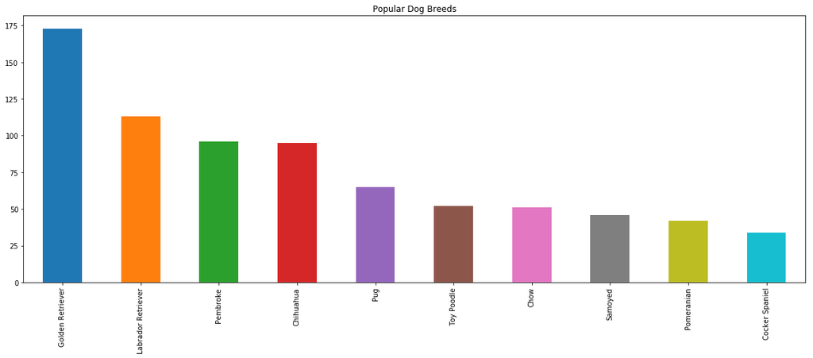

```python
# Popular Dog stage
df2 = df_combined.dog_breed.value_counts()[0:10]
df2.plot(kind="bar", figsize=(20,7), title='Popular Dog Breeds');
```

#### Observations

The above chart shows popular (top 3) dog breeds as

1. Golden Retriever
2. Labrador Retriever
3. Pembroke

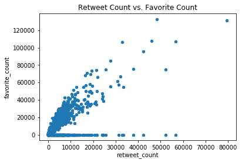

```python
##
ax = df_combined.plot.scatter(x='retweet_count',
                              y='favorite_count',
                              title='Retweet Count vs. Favorite Count')
```

#### Observations

The above scatter plot shows the relationship between favorite count and retweet count.

# References

1. https://knowledge.udacity.com/questions/578285
2. https://knowledge.udacity.com/questions/577295